# Cluster Assignment and Covariate-Constrained Randomization for Spatially-Correlated Data

##### CCR

“cvcrand” allows for custom weighting of covariate importance while performing CCR. For this example, we use standardized regression coefficients from a Poisson cell-means model with an offset via the glm() function. We are using standardized village-level data (due to the sparsity of cluster-level data); to standardize the data, the scale() function is used. The regression coefficients are standardized such that their absolute values sum to 1 - the relative weight of a given covariate is defined as the absolute value of its model coefficient divided by the sum of the absolute values of all model coefficients. To keep consistent with package author guidelines of weights greater than 1, each weight is then multiplied by 10.

```r
#Scaling covariates (not outcome or offset)
study_data_wide$scaled_microPos_1 <- scale(study_data_wide$microPos_1)
study_data_wide$scaled_BordersWater <- scale(study_data_wide$BordersWater)
study_data_wide$scaled_hhDensity <- scale(study_data_wide$hhDensity)

#Creating Poisson model with offset
weight_model <- glm(microPos_5 ~ scaled_microPos_1 + scaled_BordersWater + scaled_hhDensity+ offset(log(microTests_5)) -1,
                 data=study_data_wide, family = poisson)
summary(weight_model)
```

```
##
## Call:
## glm(formula = microPos_5 ~ scaled_microPos_1 + scaled_BordersWater +
##     scaled_hhDensity + offset(log(microTests_5)) - 1, family = poisson,
##     data = study_data_wide)
##
## Deviance Residuals:
##     Min       1Q   Median       3Q      Max
## -11.423   -8.787   -7.753   -6.016   -3.556
##
## Coefficients:
##                     Estimate Std. Error z value Pr(>|z|)
## scaled_microPos_1   -0.22025    0.02326  -9.468  < 2e-16 ***
## scaled_BordersWater -0.09691    0.02287  -4.238 2.26e-05 ***
## scaled_hhDensity     0.11830    0.02147   5.510 3.59e-08 ***
## ---
## Signif. codes:  0 '***' 0.001 '**' 0.01 '*' 0.05 '.' 0.1 ' ' 1
##
## (Dispersion parameter for poisson family taken to be 1)
##
##     Null deviance: 3557.4  on 55  degrees of freedom
## Residual deviance: 3321.9  on 52  degrees of freedom
## AIC: 3487
##
## Number of Fisher Scoring iterations: 7
```

```r
#Scaling and saving model coefficients for CCR weights
weights_raw <- c(abs(weight_model$coefficients[1][[1]])/sum(abs(weight_model$coefficients)), abs(weight_model$coefficients[2][[1]])/sum(abs(weight_model$coefficients)), abs(weight_model$coefficients[3][[1]])/sum(abs(weight_model$coefficients)))

weights <- weights_raw * 10

weights
```

```
## [1] 5.057831 2.225534 2.716635
```

“cvcrand” only allows for data sets with row number equal to the number of clusters. Thus, we first aggregate our unit-level covariate data into cluster-level summary statistics.

```r
#Subsetting variables of interest, cluster assignments
kmeans_assignments_reduced <- study_data_wide[,c("K_means_Clusters","microPos_5","microPos_1", "microTests_5","microTests_1", "BordersWater", "hhDensity")]

#Getting aggregate statistics by cluster
kmeans_assignments_reduced$Cluster_Sum_mPos_5 <- with(kmeans_assignments_reduced, ave(microPos_5, K_means_Clusters, FUN=sum))

kmeans_assignments_reduced$Cluster_Sum_mPos_1 <- with(kmeans_assignments_reduced, ave(microPos_1, K_means_Clusters, FUN=sum))

kmeans_assignments_reduced$Cluster_Sum_mTest_5 <- with(kmeans_assignments_reduced, ave(microTests_5, K_means_Clusters, FUN=sum))

kmeans_assignments_reduced$Cluster_Sum_mTest_1 <- with(kmeans_assignments_reduced, ave(microTests_1, K_means_Clusters, FUN=sum))

kmeans_assignments_reduced$Cluster_mRate_5 <- kmeans_assignments_reduced$Cluster_Sum_mPos_5 / kmeans_assignments_reduced$Cluster_Sum_mTest_5

kmeans_assignments_reduced$Cluster_mRate_1 <- kmeans_assignments_reduced$Cluster_Sum_mPos_1 / kmeans_assignments_reduced$Cluster_Sum_mTest_1

kmeans_assignments_reduced$Cluster_Med_hhDensity <- with(kmeans_assignments_reduced, ave(hhDensity, K_means_Clusters, FUN=median))

kmeans_assignments_reduced$Cluster_MeanProp_BordersWater <- with(kmeans_assignments_reduced, ave(as.numeric(BordersWater)-1, K_means_Clusters, FUN=mean))

#ensuring sorted by clustering
kmeans_assignments_reduced <- kmeans_assignments_reduced[order(kmeans_assignments_reduced$K_means_Clusters),]

#outputting one row per subgroup summary stats
kmeans_assignments_reduced <- kmeans_assignments_reduced[!duplicated(kmeans_assignments_reduced$K_means_Clusters),]
```

To perform the CCR, the cvrall() function from the “cvcrand” package is used.

Weighted:

```r
#Starting timer
start_time <- Sys.time()

#Weighted CCR
kmeans_Weighted_Design_result <- cvrall(clustername = kmeans_assignments_reduced$K_means_Clusters,
                  balancemetric = "l2",
                  x = data.frame(kmeans_assignments_reduced[ , c("Cluster_mRate_1", "Cluster_Med_hhDensity", "Cluster_MeanProp_BordersWater")]),
                  ntotal_cluster = nrow(kmeans_assignments_reduced),
                  ntrt_cluster = nrow(kmeans_assignments_reduced)/2,
                  weights = weights,
                  size = 25000000,
                  cutoff = 0.1,
                  seed = 12345)
```

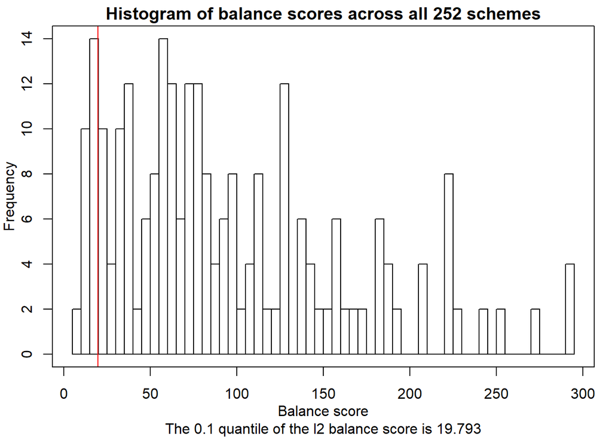

```r
#Stopping timer
end_time <- Sys.time()

#Saving CCR run time
Weighted_K_means_ccr_time <- end_time - start_time

#Adding the treatment assignments to the dataframe for visualization
weighted_allocations_kmeans <- kmeans_Weighted_Design_result$allocation
colnames(weighted_allocations_kmeans) <- c("K_means_Clusters","Weighted_K_means_Treatment_Allocation")
study_data_wide <- merge(weighted_allocations_kmeans, study_data_wide, by= "K_means_Clusters")

#Adding treatment allocations to clusters for proper labeling with spplot()
#Matching rows with SpatialPolygonsDataframe
K_kmeans_clustering <- as.data.frame(K_kmeans_clustering)
K_kmeans_clustering$id <- 1:nrow(K_kmeans_clustering)
Kmeans_clusters_weighted_ccr_1 <- merge(K_kmeans_clustering,weighted_allocations_kmeans, by = "K_means_Clusters")
Kmeans_clusters_weighted_ccr_1 <- Kmeans_clusters_weighted_ccr_1[order(Kmeans_clusters_weighted_ccr_1$id), ]
#Subsetting village code and clusters
Kmeans_clusters_weighted_ccr_1 <- Kmeans_clusters_weighted_ccr_1[,c(4,2)]
#Labeling rows
rownames(Kmeans_clusters_weighted_ccr_1) <- Kmeans_clusters_weighted_ccr_1[,2]

#Balance score for min. scheme
weighted_kmeans_ccr_min_score <- as.numeric(kmeans_Weighted_Design_result$bscores[5,2])
#Balance score for selected scheme
weighted_kmeans_ccr_selected_score <- as.numeric(kmeans_Weighted_Design_result$bscores[1,2])
#Balance score for 10% cutoff scheme
weighted_kmeans_ccr_cutoff_score <- as.numeric(kmeans_Weighted_Design_result$bscores[2,2])
#Balance score for max. scheme
weighted_kmeans_ccr_max_score <- as.numeric(kmeans_Weighted_Design_result$bscores[14,2])

#Allocation scheme
#kmeans_Weighted_Design_result$allocation

#Descriptive statistics for all the variables by the two arms from the selected scheme
#kmeans_Weighted_Design_result$baseline_table

#Dataframe with treatment allocations
#kmeans_Weighted_Design_result$data_CR
```

Unweighted:

```r
#Starting timer
start_time <- Sys.time()

#Unweighted CCR
kmeans_Unweighted_Design_result <- cvrall(clustername = kmeans_assignments_reduced$K_means_Clusters,
                  balancemetric = "l2",
                  x = data.frame(kmeans_assignments_reduced[ , c("Cluster_mRate_1", "Cluster_Med_hhDensity", "Cluster_MeanProp_BordersWater")]),
                  ntotal_cluster = length(kmeans_assignments_reduced$K_means_Clusters),
                  ntrt_cluster = length(kmeans_assignments_reduced$K_means_Clusters)/2,
                  cutoff = 0.1,
                  size = 25000000,
                  seed = 12345)
```

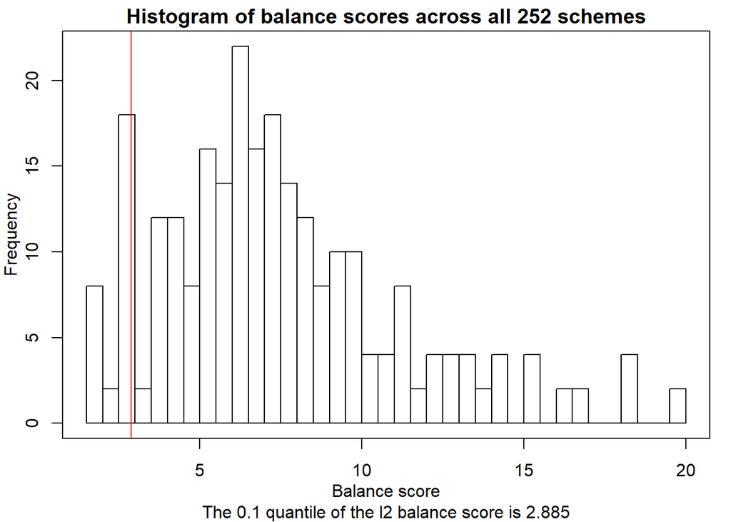

```r
#Stopping timer
end_time <- Sys.time()

#Saving ccr run time
Unweighted_K_means_ccr_time <- end_time - start_time

#Adding the treatment assignments to the dataframe for visualization
allocations_unweighted_kmeans <- kmeans_Unweighted_Design_result$allocation
colnames(allocations_unweighted_kmeans) <- c("K_means_Clusters","Unweighted_K_means_Treatment_Allocation")
study_data_wide <- merge(allocations_unweighted_kmeans, study_data_wide, by= "K_means_Clusters")

#Adding treatment allocations to clusters for proper labeling with spplot()
#Matching rows with SpatialPolygonsDataframe
Kmeans_clusters_unweighted_ccr_1 <- merge(K_kmeans_clustering,allocations_unweighted_kmeans, by = "K_means_Clusters")
Kmeans_clusters_unweighted_ccr_1 <- Kmeans_clusters_unweighted_ccr_1[order(Kmeans_clusters_unweighted_ccr_1$id), ]

#Subsetting village code and clusters
Kmeans_clusters_unweighted_ccr_1 <- Kmeans_clusters_unweighted_ccr_1[,c(4,2)]
#Labeling rows
rownames(Kmeans_clusters_unweighted_ccr_1) <- Kmeans_clusters_unweighted_ccr_1[,2]

#Balance score for min. scheme
unweighted_kmeans_ccr_min_score <- as.numeric(kmeans_Unweighted_Design_result$bscores[5,2])
#Balance score for selected scheme
unweighted_kmeans_ccr_selected_score <- as.numeric(kmeans_Unweighted_Design_result$bscores[1,2])
#Balance score for 10% cutoff scheme
unweighted_kmeans_ccr_cutoff_score <- as.numeric(kmeans_Unweighted_Design_result$bscores[2,2])
#Balance score for max. scheme
unweighted_kmeans_ccr_max_score <- as.numeric(kmeans_Unweighted_Design_result$bscores[14,2])

#Allocation scheme
#kmeans_Unweighted_Design_result$allocation

#Descriptive statistics for all the variables by the two arms from the selected scheme
#kmeans_Unweighted_Design_result$baseline_table

#Dataframe with treatment allocations
#kmeans_Unweighted_Design_result$data_CR
```

##### Measuring contiguity of treatment assignments

To measure the dispersion of treatment arms, nearest neighbor distance is found with the nndist() function from the “spatstat” package and treatment arm-level 95% confidence-level summary statistics calculated with the ci() function from the “gmodels” package. The t.test() function from base R is then used to store whether or not a significant difference was found (alpha = 0.05).

Nearest first neighbor (k = 1):

```r
#Weighted
#Treatment 0
Weighted_kmeans_treatment_0 <- subset(study_data_wide,study_data_wide$Weighted_K_means_Treatment_Allocation ==0)
Weighted_kmeans_treatment_0 <- cbind(Weighted_kmeans_treatment_0$village_long, Weighted_kmeans_treatment_0$village_lat)

#Treatment 1
Weighted_kmeans_treatment_1 <- subset(study_data_wide,study_data_wide$Weighted_K_means_Treatment_Allocation ==1)
Weighted_kmeans_treatment_1 <- cbind(Weighted_kmeans_treatment_1$village_long, Weighted_kmeans_treatment_1$village_lat)

#Saving CIs for mean nearest-neighbor distance, by treatment allocation
Weighted_kmeans_treatment_0_nndistCI_k1 <- ci(nndist(Weighted_kmeans_treatment_0), confidence = 0.95)
Weighted_kmeans_treatment_1_nndistCI_k1 <- ci(nndist(Weighted_kmeans_treatment_1), confidence = 0.95)

#Testing for significant differences in mean nn-dist with Welch Two Sample t-test
Weighted_kmeans_ttest_k1 <- t.test(nndist(Weighted_kmeans_treatment_0), nndist(Weighted_kmeans_treatment_1))
Weighted_kmeans_different_meanNNdists_k1 <- ifelse(Weighted_kmeans_ttest_k1$p.value < 0.05, 1, 0)

#Unweighted
#Treatment 0
Unweighted_kmeans_treatment_0 <- subset(study_data_wide,study_data_wide$Unweighted_K_means_Treatment_Allocation ==0)
Unweighted_kmeans_treatment_0 <- cbind(Unweighted_kmeans_treatment_0$village_long, Unweighted_kmeans_treatment_0$village_lat)

#Treatment 1
Unweighted_kmeans_treatment_1 <- subset(study_data_wide,study_data_wide$Unweighted_K_means_Treatment_Allocation ==1)
Unweighted_kmeans_treatment_1 <- cbind(Unweighted_kmeans_treatment_1$village_long, Unweighted_kmeans_treatment_1$village_lat)

#Saving CIs for mean nearest-neighbor distance, by treatment allocation
Unweighted_kmeans_treatment_0_nndistCI_k1 <- ci(nndist(Unweighted_kmeans_treatment_0), confidence = 0.95)
Unweighted_kmeans_treatment_1_nndistCI_k1 <- ci(nndist(Unweighted_kmeans_treatment_1), confidence = 0.95)

#Testing for significant differences in mean nn-dist with Welch Two Sample t-test
Unweighted_kmeans_ttest_k1 <- t.test(nndist(Unweighted_kmeans_treatment_0), nndist(Unweighted_kmeans_treatment_1))
Unweighted_kmeans_different_meanNNdists_k1 <- ifelse(Unweighted_kmeans_ttest_k1$p.value < 0.05, 1, 0)
```

#### Spatial clustering method 2: Clustering Large Applications (CLARA) with Euclidean Distance

To perform CLARA, we use the clara() function from the “cluster” package [10]. By partitioning using an actual data point located in the middle of a group of points, as opposed to an average central location with K-means, CLARA may be less sensitive to outliers.

To determine the optimal number of clusters, the same methodology provided above for K-means is used.

Let us re-initialize an array for our cluster quality statistic (average silhouette width), for every cluster size value to be tested. Again, we test between 6 and 18 clusters, and only even cluster sizes are considered.

```r
#Average Silhouette width (observation)
#Initializing cluster quality statistic matrix
ASW <- matrix(data = NA, nrow = maxclust-minclust+1, ncol = 1, byrow = FALSE,dimnames = NULL)
row.names(ASW) <- minclust:maxclust
```

Next, we iteratively collect the cluster quality statistic for each cluster size with a for() loop (note: if several values are equal to the optimal statistic, the minimum K (first value in the array) is selected).

```r
#Getting cluster quality by K

#Starting timer
start_time <- Sys.time()

#Initializing listing of cluster assignments for each value of K
clustering_list <- list()
#Initializing listing of cluster value quality for each value of K
quality_list <- list()

#Collecting cluster quality statistic across range of cluster sizes
for(i in minclust:maxclust){
  set.seed(30)
  clustering_list[[i-(minclust-1)]] <- clara(spatial_data, metric = "euclidean", k = i)$cluster
  quality_list[[i-(minclust-1)]]  <- wcClusterQuality(dt,clustering_list[[i-(minclust-1)]])
  ASW[i-(minclust-1)] <- quality_list[[i-(minclust-1)]]$stats[4]
}

#Only looking at even K values for CCR (starting from minimum K)
ASW_valid <- ASW[seq(1, nrow(ASW), 2),]

#Using average silhouette width to determine optimal K
#If several values equal to the optimal statistic, selects the minimum K (first value in array)
K_ASW <- as.numeric(names(ASW_valid)[which(ASW_valid == max(ASW_valid), arr.ind = TRUE)])[1]

#Using average silhouette width to determine optimal K
K_clara <- K_ASW

#Stopping timer
end_time <- Sys.time()

#Saving clustering selection run time
clara_selection_time <- end_time - start_time
```

After running through the sensitivity analysis to determine the optimal cluster size and saving the value, the clara() clustering algorithm is rerun with this value. The clustering scheme is then extracted and merged back into the main study data.

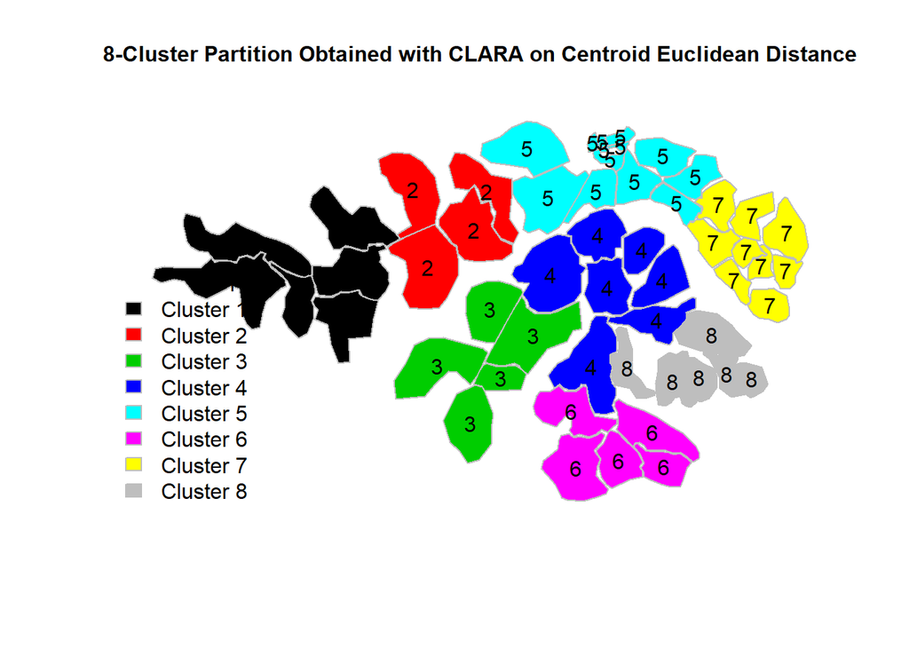

```r
#Saving cluster assignments with optimal K
K_clara_clustering <- as.matrix(clustering_list[[i-(minclust-1)]] <- clara(spatial_data, metric = "euclidean", k = K_clara)$cluster)
colnames(K_clara_clustering) <- "CLARA_Clusters"

#Adding village codes as a variable for linking
K_clara_names <- as.matrix(rownames(K_clara_clustering))
colnames(K_clara_names) <- "village_code"
K_clara_clustering <- as.matrix(cbind(K_clara_clustering,K_clara_names))

#Merging back into main dataset
study_data_wide <- merge(K_clara_clustering, study_data_wide,by = "village_code")

#Visualizing clusters
sp::plot(map,border="grey",col=K_clara_clustering, main= "8-Cluster Partition Obtained with CLARA on Centroid Euclidean Distance",cex.main=1)
legend("bottomleft", legend=paste("Cluster",1:K_clara), fill=1:K_clara, bty="n",border="grey")
text(coordinates(map), labels = K_clara_clustering[,1])
```

##### CCR

Before performing CCR again, we must create cluster-level summary statistics with the new clustering scheme.

```r
#Subsetting variables (including cluster assignments)
clara_assignments_reduced <- study_data_wide[,c("CLARA_Clusters","microPos_5","microPos_1", "microTests_5","microTests_1", "BordersWater", "hhDensity")]

#Getting cluster-level statistics
clara_assignments_reduced$Cluster_Sum_mPos_5 <- with(clara_assignments_reduced, ave(microPos_5, CLARA_Clusters, FUN=sum))

clara_assignments_reduced$Cluster_Sum_mPos_1 <- with(clara_assignments_reduced, ave(microPos_1, CLARA_Clusters, FUN=sum))

clara_assignments_reduced$Cluster_Sum_mTest_5 <- with(clara_assignments_reduced, ave(microTests_5, CLARA_Clusters, FUN=sum))

clara_assignments_reduced$Cluster_Sum_mTest_1 <- with(clara_assignments_reduced, ave(microTests_1, CLARA_Clusters, FUN=sum))

clara_assignments_reduced$Cluster_mRate_5 <- clara_assignments_reduced$Cluster_Sum_mPos_5 / clara_assignments_reduced$Cluster_Sum_mTest_5

clara_assignments_reduced$Cluster_mRate_1 <- clara_assignments_reduced$Cluster_Sum_mPos_1 / clara_assignments_reduced$Cluster_Sum_mTest_1

clara_assignments_reduced$Cluster_Med_hhDensity <- with(clara_assignments_reduced, ave(hhDensity, CLARA_Clusters, FUN=median))

clara_assignments_reduced$Cluster_MeanProp_BordersWater <- with(clara_assignments_reduced, ave(BordersWater, CLARA_Clusters, FUN=mean))

#Ensuring sorted by clustering
clara_assignments_reduced <- clara_assignments_reduced[order(clara_assignments_reduced$CLARA_Clusters),]

#Outputting one row per subgroup summary stats
clara_assignments_reduced <- clara_assignments_reduced[!duplicated(clara_assignments_reduced$CLARA_Clusters),]
```

CLARA Weighted:

```r
#Starting timer
start_time <- Sys.time()

#Weighted CCR
CLARA_Weighted_Design_result <- cvrall(clustername = clara_assignments_reduced$CLARA_Clusters,
                  balancemetric = "l2",
                  x = data.frame(clara_assignments_reduced[ , c("Cluster_mRate_1", "Cluster_Med_hhDensity", "Cluster_MeanProp_BordersWater")]),
                  ntotal_cluster = nrow(clara_assignments_reduced),
                  ntrt_cluster = nrow(clara_assignments_reduced)/2,
                  weights = weights,
                  cutoff = 0.1,
                  size = 25000000,
                  seed = 12345)
```

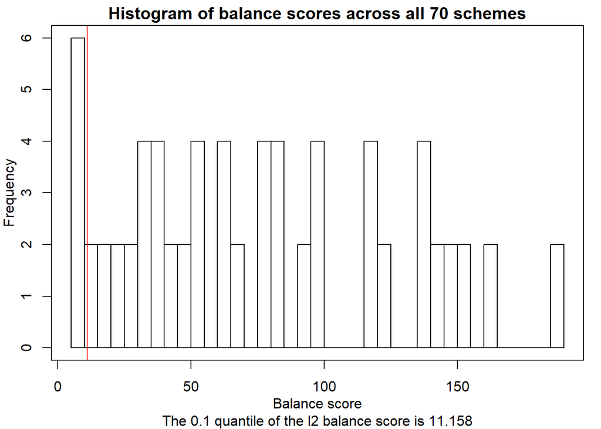

```r
#Stopping timer
end_time <- Sys.time()

#Saving CCR run time
Weighted_clara_ccr_time <- end_time - start_time

#Adding the treatment assignments to the dataframe for visualization
clara_weighted_allocations <- CLARA_Weighted_Design_result$allocation
colnames(clara_weighted_allocations) <- c("CLARA_Clusters","Weighted_CLARA_Treatment_Allocation")
study_data_wide <- merge(clara_weighted_allocations, study_data_wide, by= "CLARA_Clusters")

#Adding treatment allocations to clusters for proper labeling with spplot()
#Matching rows with SpatialPolygonsDataframe
K_clara_clustering <- as.data.frame(K_clara_clustering)
K_clara_clustering$id <- 1:nrow(K_clara_clustering)
clara_clusters_weighted_ccr_1 <- merge(K_clara_clustering,clara_weighted_allocations, by = "CLARA_Clusters")
clara_clusters_weighted_ccr_1 <- clara_clusters_weighted_ccr_1[order(clara_clusters_weighted_ccr_1$id), ]
#Subsetting village code and clusters
clara_clusters_weighted_ccr_1 <- clara_clusters_weighted_ccr_1[,c(4,2)]

#Labeling rows
rownames(clara_clusters_weighted_ccr_1) <- clara_clusters_weighted_ccr_1[,2]

#Balance score for min. scheme
weighted_clara_ccr_min_score <- as.numeric(CLARA_Weighted_Design_result$bscores[5,2])
#Balance score for selected scheme
weighted_clara_ccr_selected_score <- as.numeric(CLARA_Weighted_Design_result$bscores[1,2])
#Balance score for cutoff scheme
weighted_clara_ccr_cutoff_score <- as.numeric(CLARA_Weighted_Design_result$bscores[2,2])
#Balance score for max. scheme
weighted_clara_ccr_max_score <- as.numeric(CLARA_Weighted_Design_result$bscores[14,2])

#Allocation scheme
#CLARA_Weighted_Design_result$allocation

#Descriptive statistics for all the variables by the two arms from the selected scheme
#CLARA_Weighted_Design_result$baseline_table

#Dataframe with treatment allocations
#CLARA_Weighted_Design_result$data_CR
```

CLARA Unweighted:

```r
#Starting timer
start_time <- Sys.time()

#Unweighted CCR
CLARA_Unweighted_Design_result <- cvrall(clustername = clara_assignments_reduced$CLARA_Clusters,
                  balancemetric = "l2",
                  x = data.frame(clara_assignments_reduced[ , c("Cluster_mRate_1", "Cluster_Med_hhDensity", "Cluster_MeanProp_BordersWater")]),
                  ntotal_cluster = nrow(clara_assignments_reduced),
                  ntrt_cluster = nrow(clara_assignments_reduced)/2,
                  size = 25000000,
                  cutoff = 0.1,
                  seed = 12345)
```

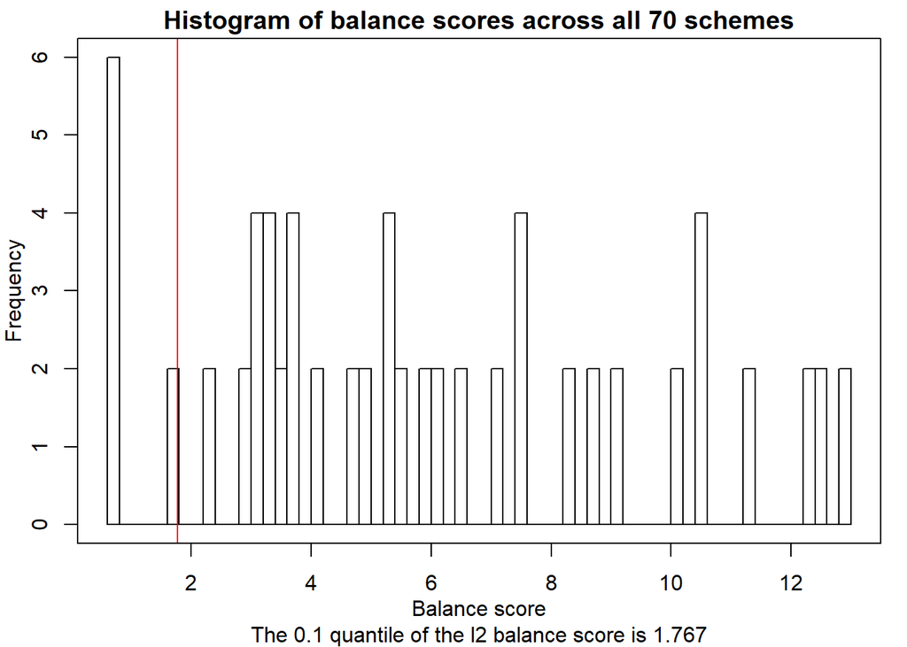

```r
#Stopping timer
end_time <- Sys.time()

#Saving CCR run time
Unweighted_clara_ccr_time <- end_time - start_time

#Adding the treatment assignments to the dataframe for visualization
clara_unweighted_allocations <- CLARA_Unweighted_Design_result$allocation
colnames(clara_unweighted_allocations) <- c("CLARA_Clusters","Unweighted_CLARA_Treatment_Allocation")
study_data_wide <- merge(clara_unweighted_allocations, study_data_wide, by= "CLARA_Clusters")

#Adding treatment allocations to clusters for proper labeling with spplot()
#Matching rows with SpatialPolygonsDataframe
clara_clusters_unweighted_ccr_1 <- merge(K_clara_clustering,clara_unweighted_allocations, by = "CLARA_Clusters")
clara_clusters_unweighted_ccr_1 <- clara_clusters_unweighted_ccr_1[order(clara_clusters_unweighted_ccr_1$id), ]
#Subsetting village code and clusters
clara_clusters_unweighted_ccr_1 <- clara_clusters_unweighted_ccr_1[,c(4,2)]

#Labeling rows
rownames(clara_clusters_unweighted_ccr_1) <- clara_clusters_unweighted_ccr_1[,2]

#Balance score for min. scheme
unweighted_clara_ccr_min_score <- as.numeric(CLARA_Unweighted_Design_result$bscores[5,2])
#Balance score for selected scheme
unweighted_clara_ccr_selected_score <- as.numeric(CLARA_Unweighted_Design_result$bscores[1,2])
#Balance score for cutoff scheme
unweighted_clara_ccr_cutoff_score <- as.numeric(CLARA_Unweighted_Design_result$bscores[2,2])
#Balance score for max. scheme
unweighted_clara_ccr_max_score <- as.numeric(CLARA_Unweighted_Design_result$bscores[14,2])

#Allocation scheme
#CLARA_Unweighted_Design_result$allocation

#Descriptive statistics for all the variables by the two arms from the selected scheme
#CLARA_Unweighted_Design_result$baseline_table

#Dataframe with treatment allocations
#CLARA_Unweighted_Design_result$data_CR
```

Comparing the dispersion of treatment arms on nearest neighbor distance (k = 1):

```r
#Weighted CCR
Weighted_clara_treatment_0 <- subset(study_data_wide,study_data_wide$Weighted_CLARA_Treatment_Allocation ==0)
Weighted_clara_treatment_0 <- cbind(Weighted_clara_treatment_0$village_long,Weighted_clara_treatment_0$village_lat)

Weighted_clara_treatment_1 <- subset(study_data_wide,study_data_wide$Weighted_CLARA_Treatment_Allocation ==1)
Weighted_clara_treatment_1 <- cbind(Weighted_clara_treatment_1$village_long,Weighted_clara_treatment_1$village_lat)

#Saving CIs for mean nearest-neighbor distance, by treatment allocation
#Treatment 0
Weighted_clara_treatment_0_nndistCI_k1 <- ci(nndist(Weighted_clara_treatment_0), confidence = 0.95)
#Treatment 1
Weighted_clara_treatment_1_nndistCI_k1 <- ci(nndist(Weighted_clara_treatment_1), confidence = 0.95)

#Testing for significant differences in mean nn-dist with Welch Two Sample t-test
Weighted_clara_ttest_k1 <- t.test(nndist(Weighted_clara_treatment_0), nndist(Weighted_clara_treatment_1))
Weighted_clara_different_meanNNdists_k1 <- ifelse(Weighted_clara_ttest_k1$p.value < 0.05, 1, 0)

#Unweighted CCR
Unweighted_clara_treatment_0 <- subset(study_data_wide,study_data_wide$Unweighted_CLARA_Treatment_Allocation ==0)
Unweighted_clara_treatment_0 <- cbind(Unweighted_clara_treatment_0$village_long, Unweighted_clara_treatment_0$village_lat)

Unweighted_clara_treatment_1 <- subset(study_data_wide,study_data_wide$Unweighted_CLARA_Treatment_Allocation ==1)
Unweighted_clara_treatment_1 <- cbind(Unweighted_clara_treatment_1$village_long, Unweighted_clara_treatment_1$village_lat)

#Saving CIs for mean nearest-neighbor distance, by treatment allocation
Unweighted_clara_treatment_0_nndistCI_k1 <- ci(nndist(Unweighted_clara_treatment_0), confidence = 0.95)
Unweighted_clara_treatment_1_nndistCI_k1 <- ci(nndist(Unweighted_clara_treatment_1), confidence = 0.95)

#Testing for significant differences in mean nn-dist with Welch Two Sample t-test
Unweighted_clara_ttest_k1 <- t.test(nndist(Unweighted_clara_treatment_0), nndist(Unweighted_clara_treatment_1))
Unweighted_clara_different_meanNNdists_k1 <- ifelse(Unweighted_clara_ttest_k1$p.value < 0.05, 1, 0)
```

#### Mixed data clustering method: Ward-like hierarchical clustering with optimized weighting of geographic-to-covariate dissimilarities

Let us take a quick look at our covariates of interest for this example:

Whether or not the unit (village) borders water (Y/N):

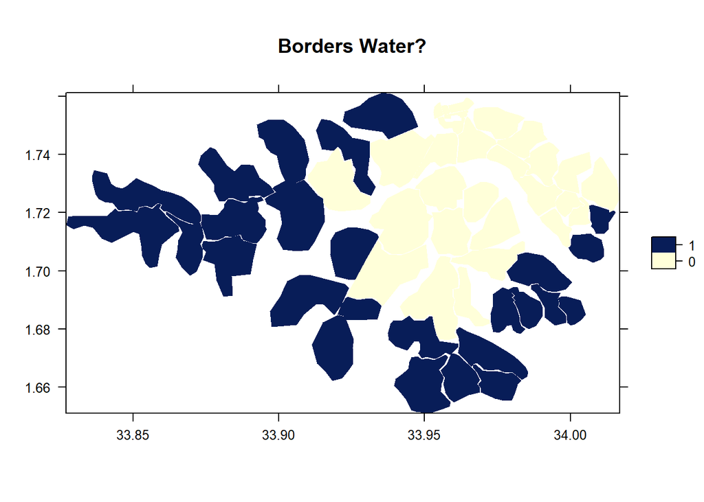

```r
#Spatially plotting covariates of interest
#Borders water indicator (ensuring factorization prior to spatial plotting)
map$BordersWater <- as.factor(map$BordersWater)
sp_out_BordersWater <- spplot(map, c("BordersWater"),
       colorkey=list(space="right"), scales = list(draw = TRUE),
       main = "Borders Water?", as.table = TRUE,
       col.regions = waterPal, col = "transparent", cuts = 1)
sp_out_BordersWater
```

Unit household density:

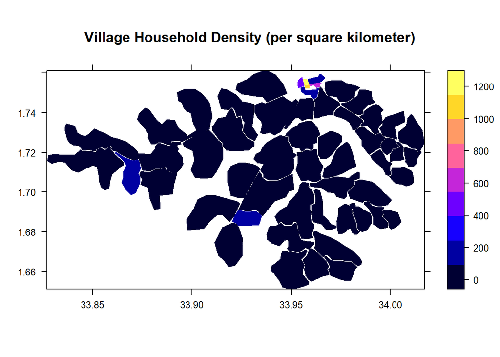

```r
#Household density
sp_out_hhDensity <- spplot(map, c("hhDensity"),
       colorkey=list(space="right"), scales = list(draw = TRUE),
       main = "Village Household Density (per square kilometer)", as.table = TRUE,
        col = "transparent", cuts = 8)
sp_out_hhDensity
```

Recent survey positive microscopy rate:

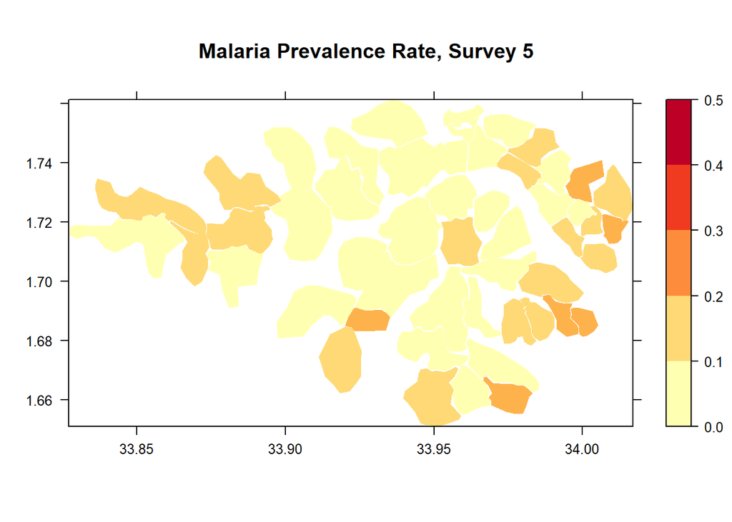

```r
#Most recent survey positive microscopy rate
sp_out_mrate5 <-spplot(map, c("mrate_5"),
       names.attr = c("Survey 5"),
       colorkey=list(space="right"), scales = list(draw = TRUE),
       main = "Malaria Prevalence Rate, Survey 5", as.table = TRUE,
       col.regions = tempPal, col = "transparent", at = seq(0, 0.5, 0.1))
sp_out_mrate5
```

The “Clustgeo” package allows users to achieve Ward-Like hierarchical clustering with non-Euclidean dissimilarity measures, and non-uniform weight. This allows accommodation of mixed data types (e.g., numeric, ordinal, binary), which may often be used for spatial feature data.

We start by extracting the primary spatial feature covariate data for the study. For this example, our spatial feature data is: recent survey positive microscopy rate for malaria; whether or not a unit borders water; and unit house-hold density.

```r
#Extracting covariate data for D0 Dissimilarity matrix
study_data_wide$BordersWater <- as.factor(study_data_wide$BordersWater)
dat <- study_data_wide[,c("mrate_5", "BordersWater", "hhDensity")]
#Assigning village code as row name for reference
rownames(dat) <- study_data_wide$village_code
```

Next, using the daisy() function from the “cluster” package, we create dissimilarity matrices for the covariates and geographical location variables separately. In addition to accommodating non-Euclidean dissimilarities, the “Clustgeo” package allows for weighting of spatial feature and geographical dissimilarity importance during cluster assignment. To test the varying weightings of dissimilarity matrices for our mixed data types, Gower dissimilarity is utilized for spatial feature data using the daisy() function - with metric set to “gower”. Briefly, Gower dissimilarity uses the Dice coefficient for binary data and range-normalized Manhattan distance for numeric data [11].

```r
#Creating D0 and D1 for cluster assignment
#Using Gower distance to accomodate mixed variable types (full matrix)
D0 = as.matrix(daisy(dat, metric = "gower"))
#Triangular matrix dist object used for calculating cluster quality
D0_dist = as.dist(D0)

#D1: geographical distance
D1 = as.matrix(daisy(spatial_data, metric = "euclidean"))
D1_dist = as.dist(D1)
```

##### Determining optimal cluster size and weighting of dissimilarity matrices

The weighting for dissimilarity matrix importance ranges from 0 to 1, in increments of 0.1 - called alpha by developers. According to the developers of the package, 0 represents full weighting on spatial feature data, 1 full weighting on geographical location. To determine the optimal cluster size and alpha level, we use the choicealpha() function from the “Clustgeo” package to calculate the proportion of explained psuedo-inertia for each cluster size of interest. The optimal alpha level is determined by the value at which the difference between the explained pseudo-inertia for covariate and geographical dissimilarity is minimized. If several values are equal to the minimized difference, then the minimum alpha value is selected.

```r
#Starting timer
start_time <- Sys.time()

#Setting max. cluster size for "ClustGeo"
maxclust_hclust <- ifelse(maxclust > 54, 54, maxclust)

#Initializing empty sets to store explained psuedo-inertia
cr <- rep(list(NA), maxclust-minclust+1)

#Covariates
Q0 <- matrix(data = NA, nrow = maxclust-minclust+1, ncol = 11, byrow = FALSE,dimnames = NULL)
row.names(Q0) <- minclust:maxclust
colnames(Q0) <- c(seq(0.0, 1.0, 0.1))

#Geographical Location
Q1 <- matrix(data = NA, nrow = maxclust-minclust+1, ncol = 11, byrow = FALSE,dimnames = NULL)
row.names(Q1) <- minclust:maxclust
colnames(Q1) <- c(seq(0.0, 1.0, 0.1))

#Setting values of alpha to optimize over
range.alpha <- seq(0,1,0.1)

#Gathering proportions of explained pseudo intertia, for every alpha and cluster size
for (w in 1:11) {
for(i in minclust:maxclust_hclust){
cr[[i-(minclust-1)]] <- choicealpha(D0_dist,D1_dist,range.alpha,i,graph=FALSE)
#Proportion of explained pseudo inertia
Q0[i-(minclust-1),w] <- cr[[i-(minclust-1)]]$Q[,1][w]
Q1[i-(minclust-1),w] <- cr[[i-(minclust-1)]]$Q[,2][w]
}}

#Minimizing difference between Q0 and Q1
Q0_Q1_diff <- abs(Q0-Q1)

#Only looking at even K values for CCR (starting from minimum K)
Q0_Q1_diff_valid <- Q0_Q1_diff[seq(1, nrow(Q0_Q1_diff), 2), ]

#Selecting optimal K as minimized magnitude difference between Q0 and Q1
K_hclust <- as.numeric(rownames(Q0_Q1_diff_valid)[which(Q0_Q1_diff_valid == min(Q0_Q1_diff_valid), arr.ind = TRUE)][1])

#Selecting optimal alpha
alpha_hclust <- as.numeric(colnames(Q0_Q1_diff_valid)[which(Q0_Q1_diff_valid == min(Q0_Q1_diff_valid), arr.ind = TRUE)][2])
#If several values equal to the minimized difference, selects the minimum alpha
alpha_hclust <- ifelse(is.na(alpha_hclust),  (which(Q0_Q1_diff_valid == min(Q0_Q1_diff_valid), arr.ind = TRUE)[1,2] - 1 )/ 10, alpha_hclust)

#Stop timer
end_time <- Sys.time()

#Saving clustering run time
hclust_selection_time <- end_time - start_time
```

To perform the clustering, the hclustgeo() function from the “Clustgeo” package is used. Unlike the standard hclust() function, hclustgeo() can automatically accommodate non-Euclidean dissimilarities, as well as custom weighting of the dendrogram arms (clusters). To keep consistent with K-means and CLARA, no weighting is used.

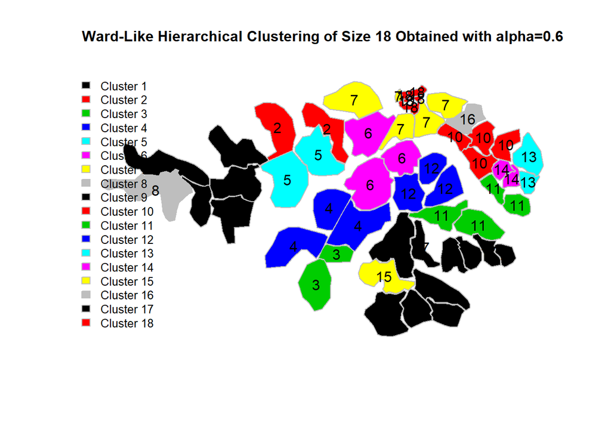

```r
#Performing hierarchical clustering
tree <- hclustgeo(D0_dist,D1_dist,alpha=alpha_hclust)
PKbis <- cutree(tree,K_hclust)#Making K cuts

#Extracting clustering scheme
PKbis_mat <- as.matrix(PKbis)
row.names(PKbis_mat) <- names(PKbis)
colnames(PKbis_mat) <- "Hierarch_Clusters"

#Adding village codes as a variable for linking
hclust_names <- as.matrix(rownames(PKbis_mat))
colnames(hclust_names) <- "village_code"
PKbis_mat <- as.matrix(cbind(PKbis_mat,hclust_names))

#Merging back hierarchical clustering scheme
study_data_wide <- merge(PKbis_mat, study_data_wide, by="village_code")
#Renaming to match SpatialPolygonsDataframe
colnames(PKbis_mat) <- c("Hierarch_Clusters", "village_sc")
poly1_noMagoro@data <- merge(PKbis_mat, poly1_noMagoro@data, by="village_sc")

#Resetting row names as a failsafe measure
row.names(study_data_wide) <- study_data_wide$village_code

#Plotting
sp::plot(map,border="grey",col=PKbis, main= "Ward-Like Hierarchical Clustering of Size 18 Obtained with alpha=0.6",cex.main=1)
legend("topleft", legend=paste("Cluster",1:max(PKbis)), fill=1:max(PKbis), bty="n",border="grey", cex=0.8)
text(coordinates(map), labels = PKbis)
```

##### CCR for Ward-like Hierarchical Clustering

```r
#Getting cluster-level statistics for hierarchical clustering scheme
hclust_assignments_reduced <- study_data_wide[,c("Hierarch_Clusters","microPos_5","microPos_1", "microTests_5","microTests_1", "BordersWater", "hhDensity")]

hclust_assignments_reduced$Cluster_Sum_mPos_5 <- with(hclust_assignments_reduced, ave(microPos_5, Hierarch_Clusters, FUN=sum))

hclust_assignments_reduced$Cluster_Sum_mPos_1 <- with(hclust_assignments_reduced, ave(microPos_1, Hierarch_Clusters, FUN=sum))

hclust_assignments_reduced$Cluster_Sum_mTest_5 <- with(hclust_assignments_reduced, ave(microTests_5, Hierarch_Clusters, FUN=sum))

hclust_assignments_reduced$Cluster_Sum_mTest_1 <- with(hclust_assignments_reduced, ave(microTests_1, Hierarch_Clusters, FUN=sum))

hclust_assignments_reduced$Cluster_mRate_5 <- hclust_assignments_reduced$Cluster_Sum_mPos_5 / hclust_assignments_reduced$Cluster_Sum_mTest_5

hclust_assignments_reduced$Cluster_mRate_1 <- hclust_assignments_reduced$Cluster_Sum_mPos_1 / hclust_assignments_reduced$Cluster_Sum_mTest_1

hclust_assignments_reduced$Cluster_Med_hhDensity <- with(hclust_assignments_reduced, ave(hhDensity, Hierarch_Clusters, FUN=median))

hclust_assignments_reduced$Cluster_MeanProp_BordersWater <- with(hclust_assignments_reduced, ave(as.numeric(BordersWater) - 1, Hierarch_Clusters, FUN=mean))

hclust_assignments_reduced$Cluster_Sum_BordersWater <- with(hclust_assignments_reduced, ave(as.numeric(BordersWater) - 1, Hierarch_Clusters, FUN=sum))

#Ensuring sorted by clustering
hclust_assignments_reduced <- hclust_assignments_reduced[order(hclust_assignments_reduced$Hierarch_Clusters),]

#Outputting one row per subgroup summary stats
hclust_assignments_reduced <- hclust_assignments_reduced[!duplicated(hclust_assignments_reduced$Hierarch_Clusters),]
```

Weighted CCR for Ward-Like Hierarchical Clustering:

```r
#Starting timer
start_time <- Sys.time()

#Weighted CCR
hclust_Weighted_Design_result <- cvrall(clustername = hclust_assignments_reduced$Hierarch_Clusters,
                  balancemetric = "l2",
                  x = data.frame(hclust_assignments_reduced[ , c("Cluster_mRate_1", "Cluster_Med_hhDensity", "Cluster_MeanProp_BordersWater")]),
                  ntotal_cluster = nrow(hclust_assignments_reduced),
                  ntrt_cluster = nrow(hclust_assignments_reduced)/2,
                  weights = weights,
                  cutoff = 0.1,
                  size = 25000000,
                  seed = 12345)
```

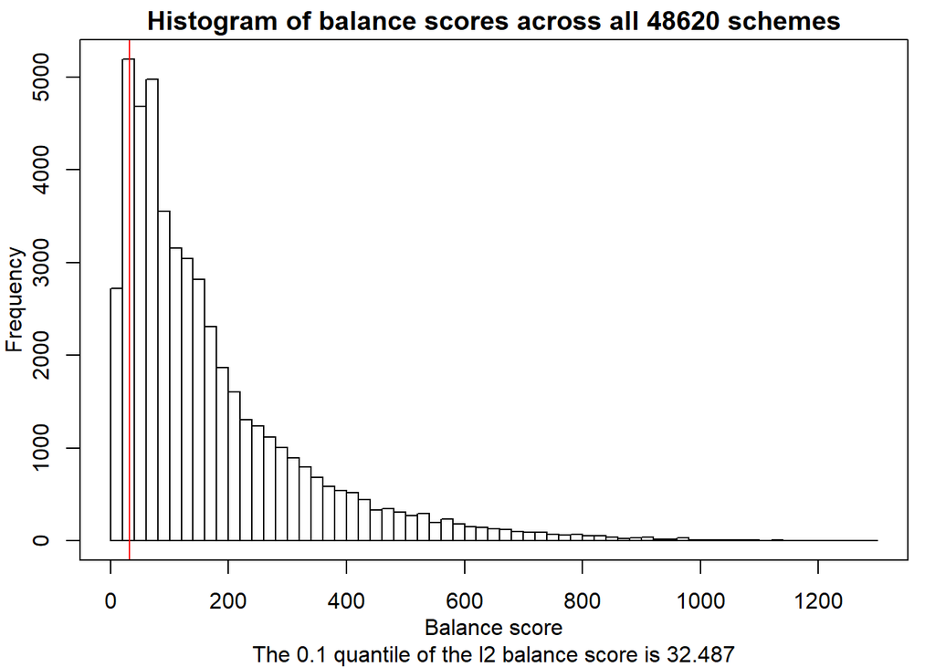

```r
#Stopping timer
end_time <- Sys.time()

#Saving CCR run time
Weighted_hclust_ccr_time <- end_time - start_time

#Adding the treatment assignments to the dataframe for visualization
hclust_weighted_allocations <- hclust_Weighted_Design_result$allocation
colnames(hclust_weighted_allocations) <- c("Hierarch_Clusters","Weighted_Hierarch_Treatment_Allocation")
study_data_wide <- merge(hclust_weighted_allocations, study_data_wide, by= "Hierarch_Clusters")

#Adding treatment allocations to clusters for proper labeling with spplot()
#Matching rows with SpatialPolygonsDataframe
K_hclust_clustering <- as.data.frame(PKbis_mat)
K_hclust_clustering$id <- 1:nrow(K_hclust_clustering)
#Merging allocations to clusters
hclust_clusters_weighted_ccr_1 <- merge(K_hclust_clustering,hclust_weighted_allocations, by = "Hierarch_Clusters")
hclust_clusters_weighted_ccr_1 <- hclust_clusters_weighted_ccr_1[order(hclust_clusters_weighted_ccr_1$id), ]
#Subsetting village code and clusters
hclust_clusters_weighted_ccr_1 <- hclust_clusters_weighted_ccr_1[,c(4,2)]
#Labeling rows
rownames(hclust_clusters_weighted_ccr_1) <- hclust_clusters_weighted_ccr_1[,2]

#Balance score for min. scheme
weighted_hclust_ccr_min_score <- as.numeric(hclust_Weighted_Design_result$bscores[5,2])
#Balance score for selected scheme
weighted_hclust_ccr_selected_score <- as.numeric(hclust_Weighted_Design_result$bscores[1,2])
#Balance score for cutoff scheme
weighted_hclust_ccr_cutoff_score <- as.numeric(hclust_Weighted_Design_result$bscores[2,2])
#Balance score for max. scheme
weighted_hclust_ccr_max_score <- as.numeric(hclust_Weighted_Design_result$bscores[14,2])

#Allocation scheme
#hclust_Weighted_Design_result$allocation

#Descriptive statistics for all the variables by the two arms from the selected scheme
#hclust_Weighted_Design_result$baseline_table

#Dataframe with treatment allocations
#hclust_Weighted_Design_result$data_CR
```

Unweighted CCR for Ward-Like Hierarchical Clustering:

```r
#Starting timer
start_time <- Sys.time()

#Unweighted CCR
hclust_Unweighted_Design_result <- cvrall(clustername = hclust_assignments_reduced$Hierarch_Clusters,
                  balancemetric = "l2",
                  x = data.frame(hclust_assignments_reduced[ , c("Cluster_mRate_1", "Cluster_Med_hhDensity", "Cluster_MeanProp_BordersWater")]),
                  ntotal_cluster = nrow(hclust_assignments_reduced),
                  ntrt_cluster = nrow(hclust_assignments_reduced)/2,
                  cutoff = 0.1,
                  size = 25000000,
                  seed = 12345)
```

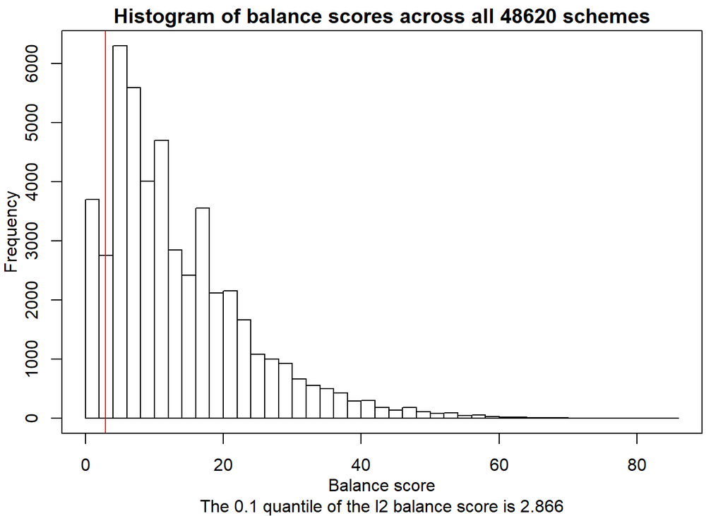

```r
#Stopping timer
end_time <- Sys.time()

#Saving CCR run time
Unweighted_hclust_ccr_time <- end_time - start_time

#Adding the treatment assignments to the dataframe for visualization
hclust_unweighted_allocations <- hclust_Unweighted_Design_result$allocation
colnames(hclust_unweighted_allocations) <- c("Hierarch_Clusters","Unweighted_Hierarch_Treatment_Allocation")
study_data_wide <- merge(hclust_unweighted_allocations, study_data_wide, by= "Hierarch_Clusters")

#Merging allocations to clusters
hclust_clusters_unweighted_ccr_1 <- merge(K_hclust_clustering,hclust_unweighted_allocations, by = "Hierarch_Clusters")
hclust_clusters_unweighted_ccr_1 <- hclust_clusters_unweighted_ccr_1[order(hclust_clusters_unweighted_ccr_1$id), ]
#Subsetting village code and clusters
hclust_clusters_unweighted_ccr_1 <- hclust_clusters_unweighted_ccr_1[,c(4,2)]
#Labeling rows
rownames(hclust_clusters_unweighted_ccr_1) <- hclust_clusters_unweighted_ccr_1[,2]

#Balance score for min. scheme
unweighted_hclust_ccr_min_score <- as.numeric(hclust_Unweighted_Design_result$bscores[5,2])
#Balance score for selected scheme
unweighted_hclust_ccr_selected_score <- as.numeric(hclust_Unweighted_Design_result$bscores[1,2])
#Balance score for cutoff scheme
unweighted_hclust_ccr_cutoff_score <- as.numeric(hclust_Unweighted_Design_result$bscores[2,2])
#Balance score for max. scheme
unweighted_hclust_ccr_max_score <- as.numeric(hclust_Unweighted_Design_result$bscores[14,2])

#Allocation scheme
#hclust_Unweighted_Design_result$allocation

#Descriptive statistics for all the variables by the two arms from the selected scheme
#hclust_Unweighted_Design_result$baseline_table

#Dataframe with treatment allocations
#hclust_Unweighted_Design_result$data_CR
```

Comparing the spatial dispersion of treatment arms on nearest neighbor distance (k = 1):

```r
#Weighted CCR
Weighted_hclust_treatment_0 <- subset(study_data_wide,study_data_wide$Weighted_Hierarch_Treatment_Allocation ==0)
Weighted_hclust_treatment_0 <- cbind(Weighted_hclust_treatment_0$village_long,Weighted_hclust_treatment_0$village_lat)

Weighted_hclust_treatment_1 <- subset(study_data_wide,study_data_wide$Weighted_Hierarch_Treatment_Allocation ==1)
Weighted_hclust_treatment_1 <- cbind(Weighted_hclust_treatment_1$village_long,Weighted_hclust_treatment_1$village_lat)

#Saving CIs for mean nearest-neighbor distance, by treatment allocation
#Treatment 0
Weighted_hclust_treatment_0_nndistCI_k1 <- ci(nndist(Weighted_hclust_treatment_0), confidence = 0.95)
#Treatment 1
Weighted_hclust_treatment_1_nndistCI_k1 <- ci(nndist(Weighted_hclust_treatment_1), confidence = 0.95)

#Testing for significant differences in mean nn-dist with Welch Two Sample t-test
Weighted_hclust_ttest_k1 <- t.test(nndist(Weighted_hclust_treatment_0), nndist(Weighted_hclust_treatment_1))
Weighted_hclust_different_meanNNdists_k1 <- ifelse(Weighted_hclust_ttest_k1$p.value < 0.05, 1, 0)

#Unweighted CCR
Unweighted_hclust_treatment_0 <- subset(study_data_wide,study_data_wide$Unweighted_Hierarch_Treatment_Allocation ==0)
Unweighted_hclust_treatment_0 <- cbind(Unweighted_hclust_treatment_0$village_long,Unweighted_hclust_treatment_0$village_lat)

Unweighted_hclust_treatment_1 <- subset(study_data_wide,study_data_wide$Unweighted_Hierarch_Treatment_Allocation ==1)
Unweighted_hclust_treatment_1 <- cbind(Unweighted_hclust_treatment_1$village_long,Unweighted_hclust_treatment_1$village_lat)

#Saving CIs for mean nearest-neighbor distance, by treatment allocation
#Treatment 0
Unweighted_hclust_treatment_0_nndistCI_k1 <- ci(nndist(Unweighted_hclust_treatment_0), confidence = 0.95)
#Treatment 1
Unweighted_hclust_treatment_1_nndistCI_k1 <- ci(nndist(Unweighted_hclust_treatment_1), confidence = 0.95)

#Testing for significant differences in mean nn-dist with Welch Two Sample t-test
Unweighted_hclust_ttest_k1 <- t.test(nndist(Unweighted_hclust_treatment_0), nndist(Unweighted_hclust_treatment_1))
Unweighted_hclust_different_meanNNdists_k1 <- ifelse(Unweighted_hclust_ttest_k1$p.value < 0.05, 1, 0)
```

##### Determining optimal cluster size using only geographic location

To determine the optimal cluster size using only location, we lock alpha at alpha = 1 (using only Q1). A sensitivity analysis is then conducted to determine the cluster size that maximizes average silhouette width.

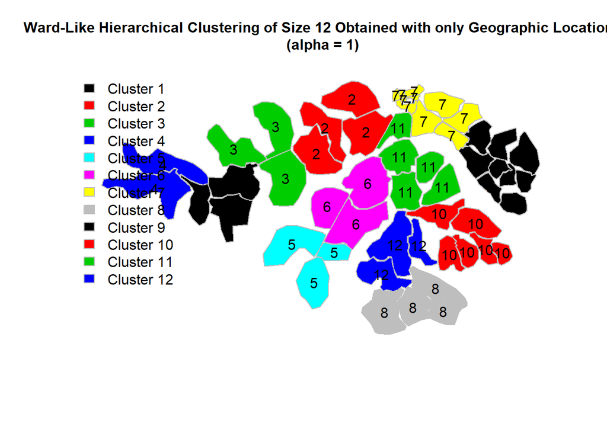

```r
#Getting cluster quality by K

#Starting timer
start_time <- Sys.time()

#Initializing listing of cluster assignments for each value of K
clustering_list <- list()
#Initializing listing of cluster value quality for each value of K
quality_list <- list()

#Average Silhouette width (observation).
ASW <- matrix(data = NA, nrow = maxclust-minclust+1, ncol = 1, byrow = FALSE,dimnames = NULL)
row.names(ASW) <- minclust:maxclust

#Performing hierarchical clustering with alpha locked at 1
tree_geo <- hclustgeo(D0_dist,D1_dist,alpha=1)

#Collecting cluster quality statistic across range of cluster sizes
for(i in minclust:maxclust_hclust){
  clustering_list[[i-(minclust-1)]] <- cutree(tree_geo,i)#Making K cuts
  quality_list[[i-(minclust-1)]]  <- wcClusterQuality(D1_dist,clustering_list[[i-(minclust-1)]])
  ASW[i-(minclust-1)] <- quality_list[[i-(minclust-1)]]$stats[4]
}

#Only looking at even K values for CCR (starting from minimum K)
ASW_valid <- ASW[seq(1, nrow(ASW), 2),]

#Using average silhouette width to determine optimal K
#If several values equal to the optimal statistic, then selects the minimum K (first value in array)
K_ASW <- as.numeric(names(ASW_valid)[which(ASW_valid == max(ASW_valid), arr.ind = TRUE)])[1]
K_hclust_geo <- K_ASW

#Stopping timer
end_time <- Sys.time()

#Saving clustering selection run time
hclust_geo_selection_time <- end_time - start_time

#Performing hierarchical clustering with optimal K
PKbis_geo <- cutree(tree_geo,K_hclust_geo)#Making K cuts

#Extracting clustering scheme
PKbis_geo_mat <- as.matrix(PKbis_geo)
row.names(PKbis_geo_mat) <- names(PKbis_geo)
colnames(PKbis_geo_mat) <- "Hierarch_Geo_Clusters"

#Adding village codes as a variable for linking
hclust_geo_names <- as.matrix(rownames(PKbis_geo_mat))
colnames(hclust_geo_names) <- "village_code"
PKbis_geo_mat <- as.matrix(cbind(PKbis_geo_mat,hclust_geo_names))

#Merging back hclust scheme
study_data_wide <- merge(PKbis_geo_mat, study_data_wide, by="village_code")

#Failsafe resetting row names
row.names(study_data_wide) <- study_data_wide$village_code

#Plotting
sp::plot(map,border="grey",col=PKbis_geo, main= "Ward-Like Hierarchical Clustering of Size 12 Obtained with only Geographic Location \n (alpha = 1)",cex.main=1)
legend("topleft", legend=paste("Cluster",1:max(PKbis_geo)), fill=1:max(PKbis_geo), bty="n",border="grey")
text(coordinates(map), labels = PKbis_geo)
```

##### CCR for Ward-like Hierarchical Clustering

```r
#Getting cluster-level statistics for hierarchical clustering scheme
hclust_geo_assignments_reduced <- study_data_wide[,c("Hierarch_Geo_Clusters","microPos_5","microPos_1", "microTests_5","microTests_1", "BordersWater", "hhDensity")]

hclust_geo_assignments_reduced$Cluster_Sum_mPos_5 <- with(hclust_geo_assignments_reduced, ave(microPos_5, Hierarch_Geo_Clusters, FUN=sum))

hclust_geo_assignments_reduced$Cluster_Sum_mPos_1 <- with(hclust_geo_assignments_reduced, ave(microPos_1, Hierarch_Geo_Clusters, FUN=sum))

hclust_geo_assignments_reduced$Cluster_Sum_mTest_5 <- with(hclust_geo_assignments_reduced, ave(microTests_5, Hierarch_Geo_Clusters, FUN=sum))

hclust_geo_assignments_reduced$Cluster_Sum_mTest_1 <- with(hclust_geo_assignments_reduced, ave(microTests_1, Hierarch_Geo_Clusters, FUN=sum))

hclust_geo_assignments_reduced$Cluster_mRate_5 <- hclust_geo_assignments_reduced$Cluster_Sum_mPos_5 / hclust_geo_assignments_reduced$Cluster_Sum_mTest_5

hclust_geo_assignments_reduced$Cluster_mRate_1 <- hclust_geo_assignments_reduced$Cluster_Sum_mPos_1 / hclust_geo_assignments_reduced$Cluster_Sum_mTest_1

hclust_geo_assignments_reduced$Cluster_Med_hhDensity <- with(hclust_geo_assignments_reduced, ave(hhDensity, Hierarch_Geo_Clusters, FUN=median))

hclust_geo_assignments_reduced$Cluster_MeanProp_BordersWater <- with(hclust_geo_assignments_reduced, ave(as.numeric(BordersWater) - 1, Hierarch_Geo_Clusters, FUN=mean))

hclust_geo_assignments_reduced$Cluster_Sum_BordersWater <- with(hclust_geo_assignments_reduced, ave(as.numeric(BordersWater) - 1, Hierarch_Geo_Clusters, FUN=sum))

#Ensuring sorted by clustering
hclust_geo_assignments_reduced <- hclust_geo_assignments_reduced[order(hclust_geo_assignments_reduced$Hierarch_Geo_Clusters),]

#Outputting one row per subgroup summary stats
hclust_geo_assignments_reduced <- hclust_geo_assignments_reduced[!duplicated(hclust_geo_assignments_reduced$Hierarch_Geo_Clusters),]
```

Weighted CCR for Ward-Like Hierarchical Clustering (Euclidean Distance Only):

```r
#Starting timer
start_time <- Sys.time()

#Weighted CCR
hclust_geo_Weighted_Design_result <- cvrall(clustername = hclust_geo_assignments_reduced$Hierarch_Geo_Clusters,
                  balancemetric = "l2",
                  x = data.frame(hclust_geo_assignments_reduced[ , c("Cluster_mRate_1", "Cluster_Med_hhDensity", "Cluster_MeanProp_BordersWater")]),
                  ntotal_cluster = nrow(hclust_geo_assignments_reduced),
                  ntrt_cluster = nrow(hclust_geo_assignments_reduced)/2,
                  weights = weights,
                  cutoff = 0.1,
                  size = 25000000,
                  seed = 12345)
```

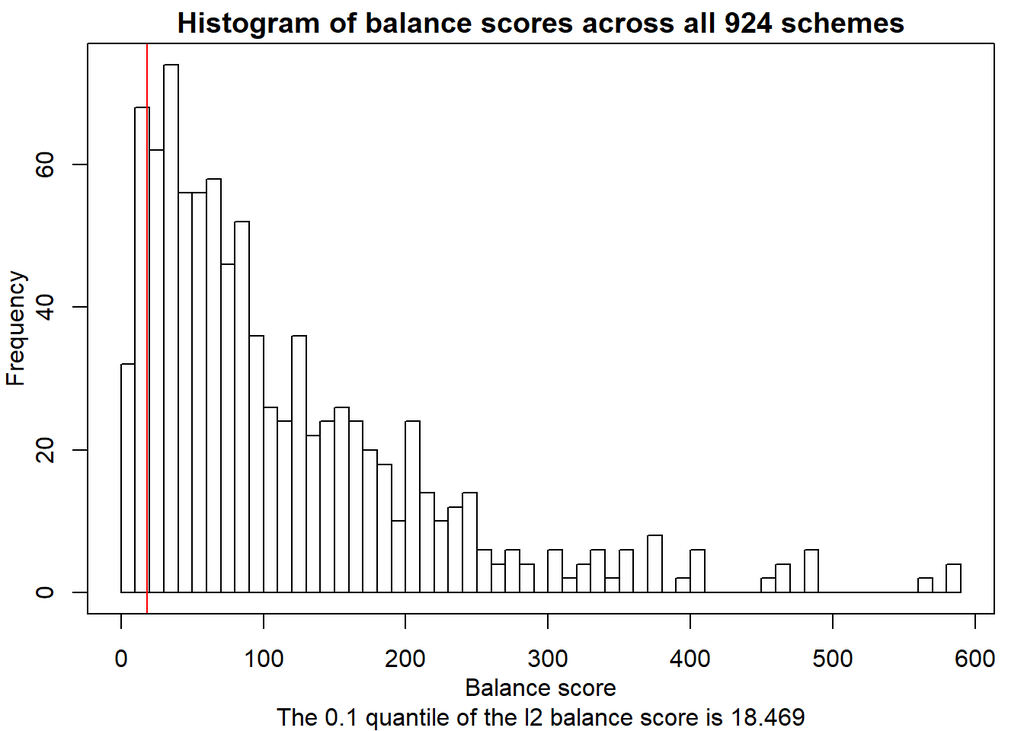

```r
#Stopping timer
end_time <- Sys.time()

#Saving CCR run time
Weighted_hclust_geo_ccr_time <- end_time - start_time

#Adding the treatment assignments to the dataframe for visualization
hclust_geo_weighted_allocations <- hclust_geo_Weighted_Design_result$allocation
colnames(hclust_geo_weighted_allocations) <- c("Hierarch_Geo_Clusters","Weighted_Hierarch_Geo_Treatment_Allocation")
study_data_wide <- merge(hclust_geo_weighted_allocations, study_data_wide, by= "Hierarch_Geo_Clusters")

#Adding treatment allocations to clusters for proper labeling with spplot()
#Matching rows with SpatialPolygonsDataframe
K_hclust_geo_clustering <- as.data.frame(PKbis_geo_mat)
K_hclust_geo_clustering$id <- 1:nrow(K_hclust_geo_clustering)
#Merging allocations to clusters
hclust_geo_clusters_weighted_ccr_1 <- merge(K_hclust_geo_clustering,hclust_geo_weighted_allocations, by = "Hierarch_Geo_Clusters")
hclust_geo_clusters_weighted_ccr_1 <- hclust_geo_clusters_weighted_ccr_1[order(hclust_geo_clusters_weighted_ccr_1$id), ]
#Subsetting village code and clusters
hclust_geo_clusters_weighted_ccr_1 <- hclust_geo_clusters_weighted_ccr_1[,c(4,2)]
#Labeling rows
rownames(hclust_geo_clusters_weighted_ccr_1) <- hclust_geo_clusters_weighted_ccr_1[,2]

#Balance score for min. scheme
weighted_hclust_geo_ccr_min_score <- as.numeric(hclust_geo_Weighted_Design_result$bscores[5,2])
#Balance score for selected scheme
weighted_hclust_geo_ccr_selected_score <- as.numeric(hclust_geo_Weighted_Design_result$bscores[1,2])
#Balance score for cutoff scheme
weighted_hclust_geo_ccr_cutoff_score <- as.numeric(hclust_geo_Weighted_Design_result$bscores[2,2])
#Balance score for max. scheme
weighted_hclust_geo_ccr_max_score <- as.numeric(hclust_geo_Weighted_Design_result$bscores[14,2])

#Allocation scheme
#hclust_geo_Weighted_Design_result$allocation

#Descriptive statistics for all the variables by the two arms from the selected scheme
#hclust_geo_Weighted_Design_result$baseline_table

#Dataframe with treatment allocations
#hclust_geo_Weighted_Design_result$data_CR
```

Unweighted CCR for Ward-Like Hierarchical Clustering (Euclidean Distance Only):

```r
#Starting timer
start_time <- Sys.time()

#Unweighted CCR
hclust_geo_Unweighted_Design_result <- cvrall(clustername = hclust_geo_assignments_reduced$Hierarch_Geo_Clusters,
                  balancemetric = "l2",
                  x = data.frame(hclust_geo_assignments_reduced[ , c("Cluster_mRate_1", "Cluster_Med_hhDensity", "Cluster_MeanProp_BordersWater")]),
                  ntotal_cluster = nrow(hclust_geo_assignments_reduced),
                  ntrt_cluster = nrow(hclust_geo_assignments_reduced)/2,
                  cutoff = 0.1,
                  size = 25000000,
                  seed = 12345)
```

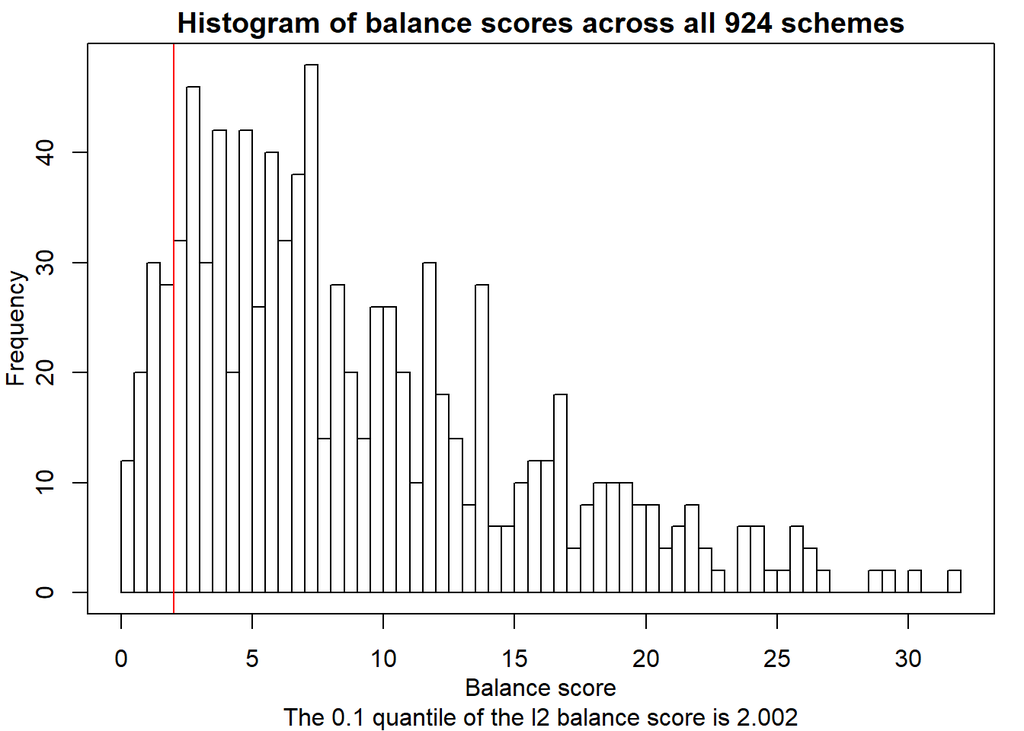

```r
#Stopping timer
end_time <- Sys.time()

#Saving CCR run time
Unweighted_hclust_geo_ccr_time <- end_time - start_time

#Adding the treatment assignments to the dataframe for visualization
hclust_geo_unweighted_allocations <- hclust_geo_Unweighted_Design_result$allocation
colnames(hclust_geo_unweighted_allocations) <- c("Hierarch_Geo_Clusters","Unweighted_Hierarch_Geo_Treatment_Allocation")
study_data_wide <- merge(hclust_geo_unweighted_allocations, study_data_wide, by= "Hierarch_Geo_Clusters")

#Merging allocations to clusters
hclust_geo_clusters_unweighted_ccr_1 <- merge(K_hclust_geo_clustering,hclust_geo_unweighted_allocations, by = "Hierarch_Geo_Clusters")
hclust_geo_clusters_unweighted_ccr_1 <- hclust_geo_clusters_unweighted_ccr_1[order(hclust_geo_clusters_unweighted_ccr_1$id), ]
#Subsetting village code and clusters
hclust_geo_clusters_unweighted_ccr_1 <- hclust_geo_clusters_unweighted_ccr_1[,c(4,2)]
#Labeling rows
rownames(hclust_geo_clusters_unweighted_ccr_1) <- hclust_geo_clusters_unweighted_ccr_1[,2]

#Balance score for min. scheme
unweighted_hclust_geo_ccr_min_score <- as.numeric(hclust_geo_Unweighted_Design_result$bscores[5,2])
#Balance score for selected scheme
unweighted_hclust_geo_ccr_selected_score <- as.numeric(hclust_geo_Unweighted_Design_result$bscores[1,2])
#Balance score for cutoff scheme
unweighted_hclust_geo_ccr_cutoff_score <- as.numeric(hclust_geo_Unweighted_Design_result$bscores[2,2])
#Balance score for max. scheme
unweighted_hclust_geo_ccr_max_score <- as.numeric(hclust_geo_Unweighted_Design_result$bscores[14,2])

#Allocation scheme
#hclust_geo_Unweighted_Design_result$allocation

#Descriptive statistics for all the variables by the two arms from the selected scheme
#hclust_geo_Unweighted_Design_result$baseline_table

#Dataframe with treatment allocations
#hclust_geo_Unweighted_Design_result$data_CR
```

Comparing the spatial dispersion of treatment arms on nearest neighbor distance (k = 1):

```r
#Weighted CCR
#Treatment 0
Weighted_hclust_geo_treatment_0 <- subset(study_data_wide,study_data_wide$Weighted_Hierarch_Geo_Treatment_Allocation ==0)
Weighted_hclust_geo_treatment_0 <- cbind(Weighted_hclust_geo_treatment_0$village_long,Weighted_hclust_geo_treatment_0$village_lat)
#Treatment 1
Weighted_hclust_geo_treatment_1 <- subset(study_data_wide,study_data_wide$Weighted_Hierarch_Geo_Treatment_Allocation ==1)
Weighted_hclust_geo_treatment_1 <- cbind(Weighted_hclust_geo_treatment_1$village_long,Weighted_hclust_geo_treatment_1$village_lat)

#Saving CIs for mean nearest-neighbor distance, by treatment arm
#Treatment 0
Weighted_hclust_geo_treatment_0_nndistCI_k1 <- ci(nndist(Weighted_hclust_geo_treatment_0), confidence = 0.95)
#Treatment 1
Weighted_hclust_geo_treatment_1_nndistCI_k1 <- ci(nndist(Weighted_hclust_geo_treatment_1), confidence = 0.95)

#Testing for significant differences in treatment arm mean nearest-neighbor distance with Welch Two Sample t-test
Weighted_hclust_geo_ttest_k1 <- t.test(nndist(Weighted_hclust_geo_treatment_0), nndist(Weighted_hclust_geo_treatment_1))
Weighted_hclust_geo_different_meanNNdists_k1 <- ifelse(Weighted_hclust_geo_ttest_k1$p.value < 0.05, 1, 0)

#Unweighted CCR
#Treatment 0
Unweighted_hclust_geo_treatment_0 <- subset(study_data_wide,study_data_wide$Unweighted_Hierarch_Geo_Treatment_Allocation ==0)
Unweighted_hclust_geo_treatment_0 <- cbind(Unweighted_hclust_geo_treatment_0$village_long,Unweighted_hclust_geo_treatment_0$village_lat)
#Treatment 1
Unweighted_hclust_geo_treatment_1 <- subset(study_data_wide,study_data_wide$Unweighted_Hierarch_Geo_Treatment_Allocation ==1)
Unweighted_hclust_geo_treatment_1 <- cbind(Unweighted_hclust_geo_treatment_1$village_long,Unweighted_hclust_geo_treatment_1$village_lat)

#Saving CIs for mean nearest-neighbor distance, by treatment arm
#Treatment 0
Unweighted_hclust_geo_treatment_0_nndistCI_k1 <- ci(nndist(Unweighted_hclust_geo_treatment_0), confidence = 0.95)
#Treatment 1
Unweighted_hclust_geo_treatment_1_nndistCI_k1 <- ci(nndist(Unweighted_hclust_geo_treatment_1), confidence = 0.95)

#Testing for significant differences in treatment arm mean nearest-neighbor distance with Welch Two Sample t-test
Unweighted_hclust_geo_ttest_k1 <- t.test(nndist(Unweighted_hclust_geo_treatment_0), nndist(Unweighted_hclust_geo_treatment_1))
Unweighted_hclust_geo_different_meanNNdists_k1 <- ifelse(Unweighted_hclust_geo_ttest_k1$p.value < 0.05, 1, 0)
```

### Results

#### CCR Scores

```
##                                Minimum Score Selected Balance Score
## K-Means Weighted                       9.536                 15.931
## K-Means Unweighted                     1.592                  2.651
## CLARA Weighted                         6.636                  9.297
## CLARA Unweighted                       0.716                  0.776
## H-Clust Weighted - Geo. Only           1.968                  4.280
## H-Clust Unweighted - Geo. Only         0.242                  0.625
## H-Clust Weighted                       0.000                  0.074
## H-Clust Unweighted                     0.000                  0.011
##                                10% Cutoff Score Maximum Score
## K-Means Weighted                         19.793       292.706
## K-Means Unweighted                        2.885        19.701
## CLARA Weighted                           11.158       188.558
## CLARA Unweighted                          1.767        12.921
## H-Clust Weighted - Geo. Only             18.469       581.351
## H-Clust Unweighted - Geo. Only            2.002        31.655
## H-Clust Weighted                         32.487      1293.510
## H-Clust Unweighted                        2.866        84.845
##                                Number of Clusters in Each Treatment Arm
## K-Means Weighted                                                      5
## K-Means Unweighted                                                    5
## CLARA Weighted                                                        4
## CLARA Unweighted                                                      4
## H-Clust Weighted - Geo. Only                                          6
## H-Clust Unweighted - Geo. Only                                        6
## H-Clust Weighted                                                      9
## H-Clust Unweighted                                                    9
##                                Number of Allocations in Randomization Space
## K-Means Weighted                                                         25
## K-Means Unweighted                                                       25
## CLARA Weighted                                                            7
## CLARA Unweighted                                                          7
## H-Clust Weighted - Geo. Only                                             92
## H-Clust Unweighted - Geo. Only                                           92
## H-Clust Weighted                                                       4862
## H-Clust Unweighted                                                     4862
```

### CCR Treatment Arm Contiguity (Measured with Mean Nearest Neighbor Distance)

```
##                                                         Mean Nearest Neighbor Distance (k = 1)
## K-Means with Weighted CCR: Treatment 0                                             0.010472097
## K-Means with Weighted CCR: Treatment 1                                             0.009837955
## K-Means with Unweighted CCR: Treatment 0                                           0.008619837
## K-Means with Unweighted CCR: Treatment 1                                           0.012766744
## CLARA with Weighted CCR: Treatment 0                                               0.010401031
## CLARA with Weighted CCR: Treatment 1                                               0.009809184
## CLARA with Unweighted CCR: Treatment 0                                             0.009089061
## CLARA with Unweighted CCR: Treatment 1                                             0.011707411
## Hierarchical with Weighted CCR - Geo. Only: Treatment 0                            0.011423206
## Hierarchical with Weighted CCR - Geo. Only: Treatment 1                            0.015352918
## Hierarchical with Unweighted CCR: Treatment 0                                      0.012650389
## Hierarchical with Unweighted CCR: Treatment 1                                      0.012682056
## Hierarchical with Weighted CCR: Treatment 0                                        0.011633449
## Hierarchical with Weighted CCR: Treatment 1                                        0.012982177
## Hierarchical with Unweighted CCR: Treatment 0                                      0.011939494
## Hierarchical with Unweighted CCR: Treatment 1                                      0.013373530
##                                                            CI lower    CI upper
## K-Means with Weighted CCR: Treatment 0                  0.008912511 0.012031682
## K-Means with Weighted CCR: Treatment 1                  0.008233682 0.011442227
## K-Means with Unweighted CCR: Treatment 0                0.007254675 0.009984999
## K-Means with Unweighted CCR: Treatment 1                0.011275031 0.014258456
## CLARA with Weighted CCR: Treatment 0                    0.008364662 0.012437400
## CLARA with Weighted CCR: Treatment 1                    0.008623046 0.010995321
## CLARA with Unweighted CCR: Treatment 0                  0.007222564 0.010955558
## CLARA with Unweighted CCR: Treatment 1                  0.010257170 0.013157651
## Hierarchical with Weighted CCR - Geo. Only: Treatment 0 0.009042613 0.013803799
## Hierarchical with Weighted CCR - Geo. Only: Treatment 1 0.012823700 0.017882137
## Hierarchical with Unweighted CCR: Treatment 0           0.009660288 0.015640490
## Hierarchical with Unweighted CCR: Treatment 1           0.010699720 0.014664392
## Hierarchical with Weighted CCR: Treatment 0             0.009176190 0.014090709
## Hierarchical with Weighted CCR: Treatment 1             0.009735588 0.016228766
## Hierarchical with Unweighted CCR: Treatment 0           0.008861495 0.015017492
## Hierarchical with Unweighted CCR: Treatment 1           0.010672703 0.016074357
##                                                           Std. Error
## K-Means with Weighted CCR: Treatment 0                  0.0007499400
## K-Means with Weighted CCR: Treatment 1                  0.0007875921
## K-Means with Unweighted CCR: Treatment 0                0.0006710010
## K-Means with Unweighted CCR: Treatment 1                0.0007151193
## CLARA with Weighted CCR: Treatment 0                    0.0009906786
## CLARA with Weighted CCR: Treatment 1                    0.0005780875
## CLARA with Unweighted CCR: Treatment 0                  0.0009096739
## CLARA with Unweighted CCR: Treatment 1                  0.0007055314
## Hierarchical with Weighted CCR - Geo. Only: Treatment 0 0.0011672357
## Hierarchical with Weighted CCR - Geo. Only: Treatment 1 0.0012195629
## Hierarchical with Unweighted CCR: Treatment 0           0.0014518304
## Hierarchical with Unweighted CCR: Treatment 1           0.0009677451
## Hierarchical with Weighted CCR: Treatment 0             0.0011954389
## Hierarchical with Weighted CCR: Treatment 1             0.0015822892
## Hierarchical with Unweighted CCR: Treatment 0           0.0015026304
## Hierarchical with Unweighted CCR: Treatment 1           0.0013113749
```

```
##                                     Difference in cluster spatial variability (k = 1)? (0 = No, 1 = Yes)
## Weighted K-Means                                                                                       0
## Unweighted K-Means                                                                                     1
## Weighted CLARA                                                                                         0
## Unweighted CLARA                                                                                       1
## Weighted Hierarchical - Geo. Only                                                                      1
## Unweighted Hierarchical - Geo. Only                                                                    0
## Weighted Hierarchical                                                                                  0
## Unweighted Hierarchical                                                                                0
```

### CPU Run Times

```
##                     K-Means Time (seconds) CLARA Time (seconds)
## Optimizing Clusters             0.04986691           0.06080008
## Weighted CCR                    0.12266994           0.04488492
## Unweighted CCR                  0.02689099           0.04787087
##                     H-Clust Geo. Time (seconds)
## Optimizing Clusters                  0.04185700
## Weighted CCR                         0.02918506
## Unweighted CCR                       0.02792597
##                     H-Clust Time Euc. Geo./Gower Cov. (seconds)
## Optimizing Clusters                                   7.5198622
## Weighted CCR                                          0.2646990
## Unweighted CCR                                        0.2483048
```

In terms of CPU run times, Ward-like hierarchical clustering with mixed dissimilarities took the longest to run, due to its cluster optimization phase, though by only a few extra seconds. All three geographic location-only methods appear to have no clear differences between them, and are somewhat comparable to one another.

### Visualization of Treatment Allocations

#### K-Means

[figure not shown]

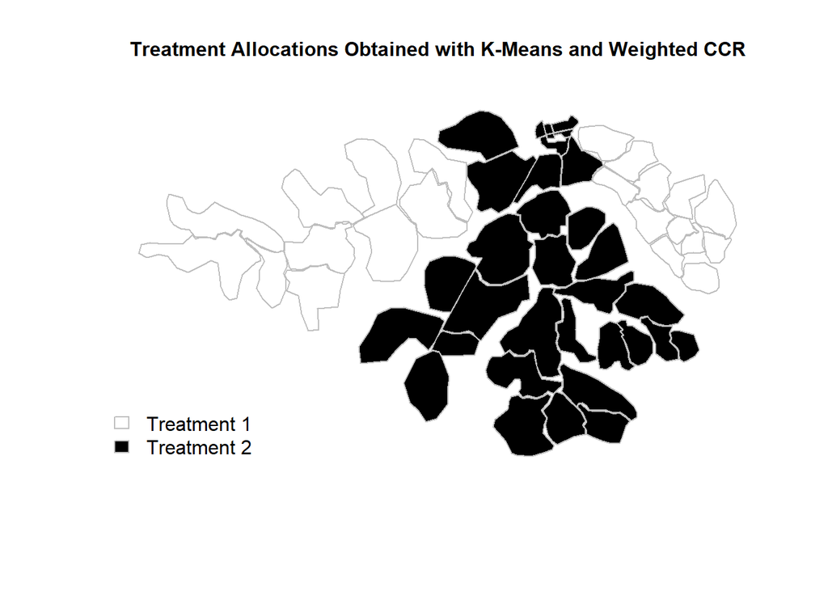

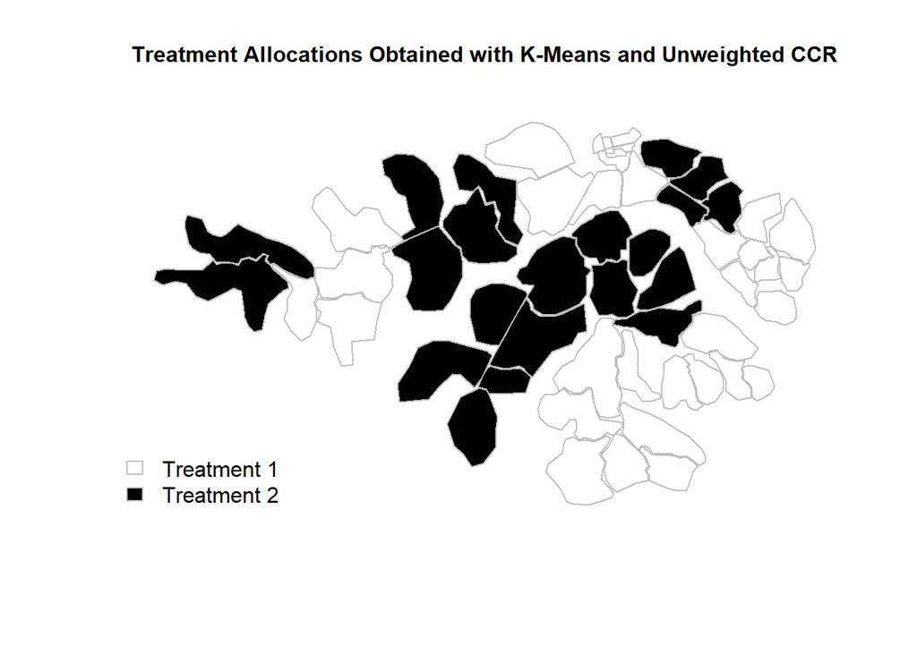

#### CLARA

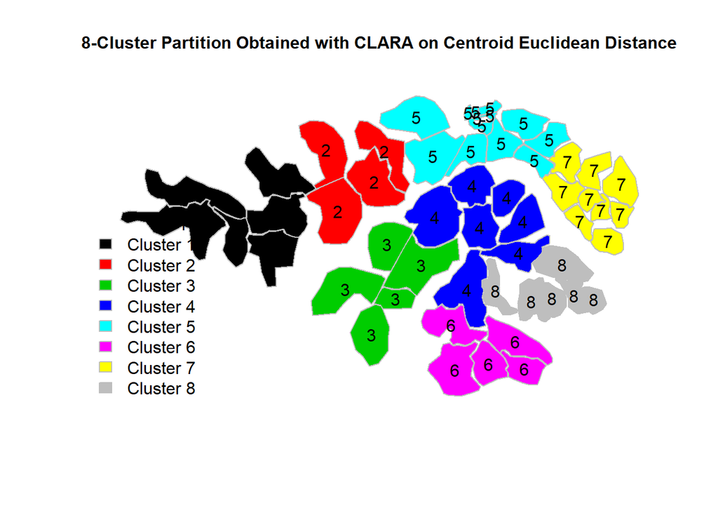

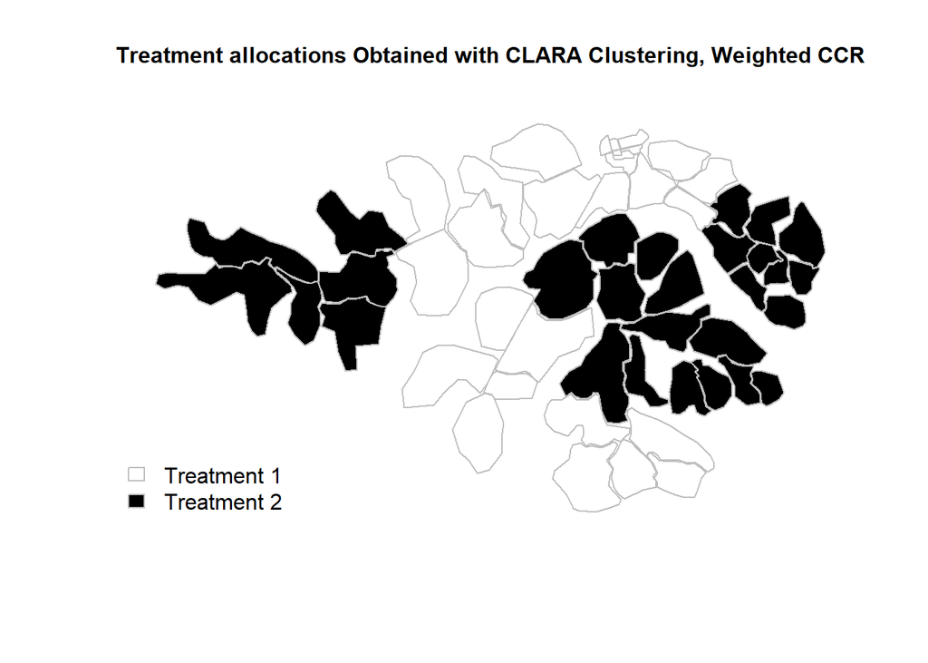

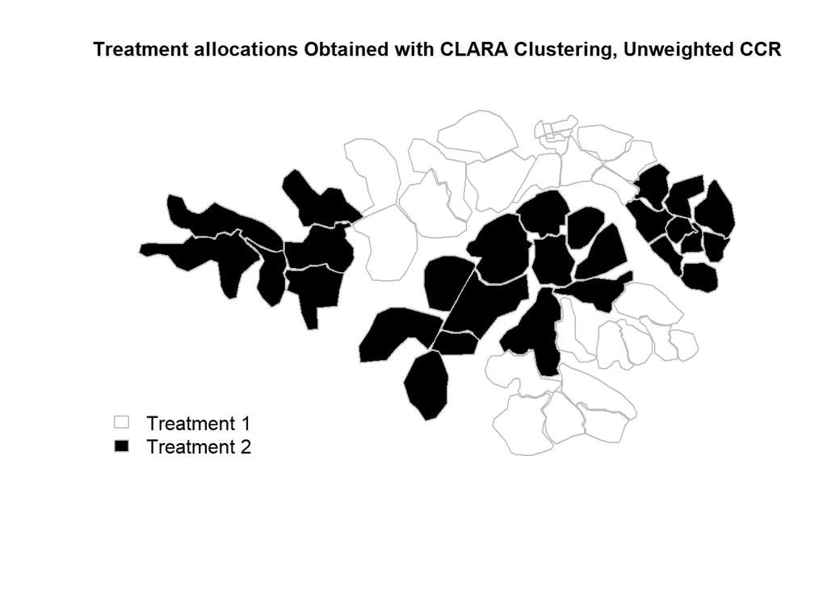

#### Ward-Like Hierarchical Clustering with Euclidean Distance

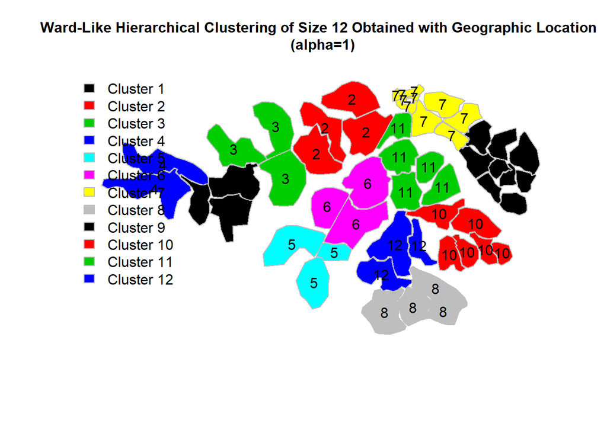

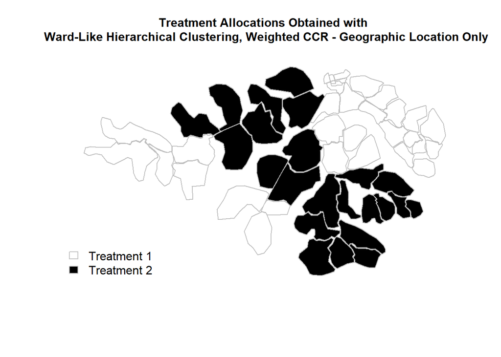

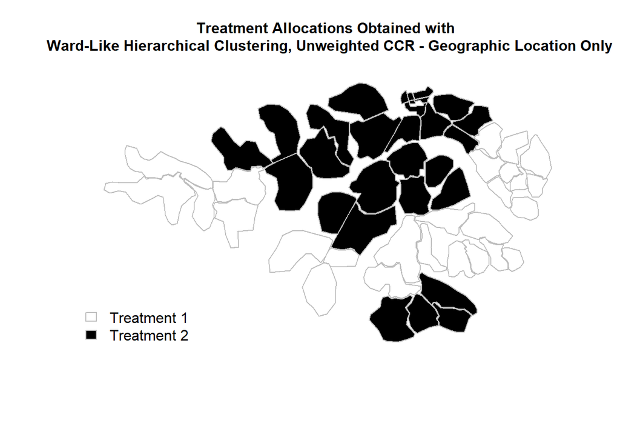

#### Ward-Like Hierarchical Clustering with Euclidean Distance and Mixed Covariate Dissimilarity

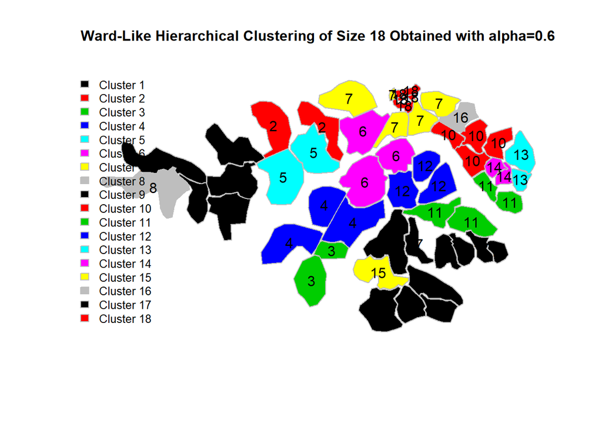

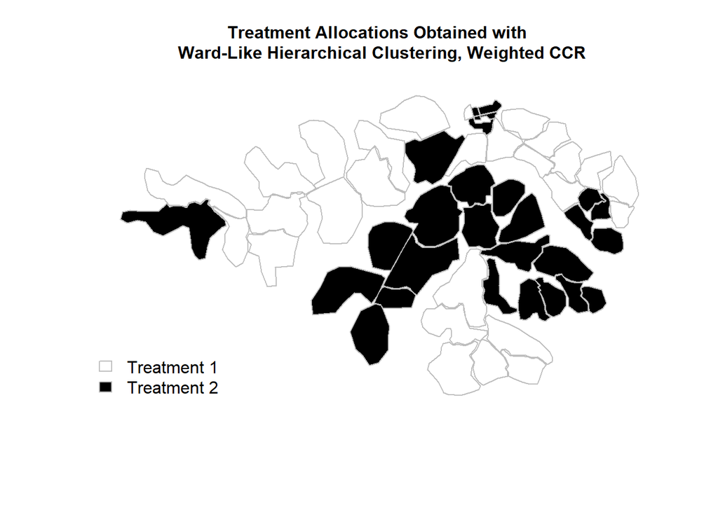

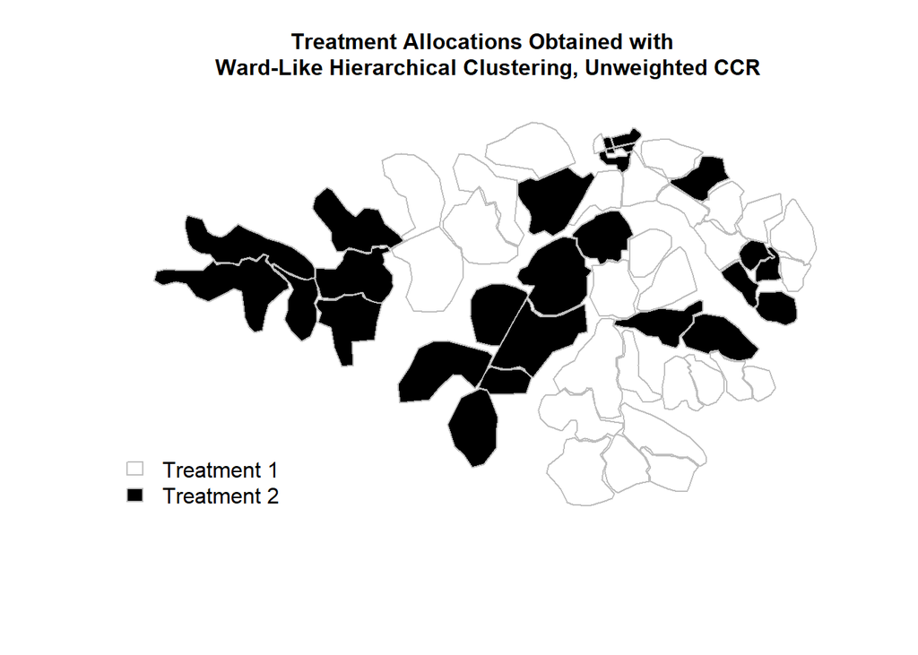

### Conclusions

In terms of minimizing covariate imbalance, Ward-like hierarchical using only geographic location (Euclidean distance) and weighting during CCR appears to perform better than the more complicated, and more computationally-intensive, mixed-dissimilarity method. For CRT design using Ward-like hierarchical clustering with weighted CCR, this added level of sophistication may be unnecessary. Clustering on geographic location, then performing CCR, may sufficiently balance treatment arms with respect to important spatial feature data. For some studies, if a straight-line path is not possible (e.g., a grid of city streets), it may be impractical to use Euclidean distance between units. For such a scenario, using Manhattan distance is preferable; however, it should be noted that K-means gives better results (i.e., less distortion) when using Euclidean distance [12].

In this paper, we presented a stepwise methodological approach to mitigating covariate imbalance and intervention contamination in a CRT. This approach cannot ensure that only treatment assignments exhibiting spatial heterogeneity are randomly selected from. Future enhancements to this approach might include optimization of covariate imbalance and spatial clustering of intervention arms simultaneously.

### Limitations

For simplicity, the only cluster quality statistic used to optimize clustering methods was average silhouette width. It may be of interest to examine additional, potential cluster quality statistics that are applicable for clustering on a variety of data types (e.g., numerical, nominal, ordinal). Furthermore, “ClustGeo” limits the maximum number of clusters to 55; this may be impractical for some large CRT studies. For large CRTs, K-means or CLARA - or an alternate method of hierarchical clustering - may be preferable to Ward-Like hierarchical clustering with “ClustGeo”.

Clustering and treatment assignments, as well as conclusions on spatial heterogeneity of treatment assignments, may be influenced by geographical barriers between units (e.g., mountains, canyons, swamps). These barriers may prevent spatial contamination of subjects across units, but they were not considered in the applications presented here.

Unlike the spatial clustering methods outlined here, density-based spatial clustering methods (e.g., DBSCAN) can detect clusters of arbitrary shape [13]. As the geographic region for this and many studies is oblong, and not uniformly- distributed, such an algorithm may be of use for assigning units to CRT treatment arms. Unfortunately, as it is not a hard clustering algorithm and may result in some units belonging to multiple or no clusters, density-based clustering was not considered in this example.

### References

1. Moulton, L. (2004). Covariate-based constrained randomization of group-randomized trials. Clinical Trials. 1: 297-305.
2. Pebesma, E.J., R.S. Bivand. (2005). Classes and methods for spatial data in R. R News 5 (2), https://cran.r-project.org/doc/Rnews/.
3. Roger S. Bivand, Edzer Pebesma, Virgilio Gomez-Rubio. (2013). Applied spatial data analysis with R, Second edition. Springer, NY. http://www.asdar-book.org/.
4. H. Wickham. (2016). ggplot2: Elegant Graphics for Data Analysis. Springer-Verlag New York.
5. Studer, Matthias (2013). WeightedCluster Library Manual: A practical guide to creating typologies of trajectories in the social sciences with R. LIVES Working Papers, 24. DOI: 10.12682/lives.2296-1658.2013.24.
6. Marie Chavent, Vanessa Kuentz, Amaury Labenne and Jerome Saracco (2017). ClustGeo: Hierarchical Clustering with Spatial Constraints. R package version 2.0. https://CRAN.R-project.org/package=ClustGeo.
7. Maechler, M. Cluster. Retrived from https://www.rdocumentation.org/packages/cluster/versions/2.0.7-1/topics/daisy.
8. Hengshi Yu, Fan Li, John A. Gallis and Elizabeth L. Turner (2019). cvcrand: Efficient Design and Analysis of Cluster Randomized Trials. R package version 0.0.3. https://CRAN.R-project.org/package=cvcrand.
9. Adrian Baddeley, Ege Rubak, Rolf Turner (2015). Spatial Point Patterns: Methodology and Applications with R. London: Chapman and Hall/CRC Press, 2015. http://www.crcpress.com/Spatial-Point-Patterns-Methodology-and-Applications-with-R/Baddeley-Rubak-Turner/9781482210200/.
10. Maechler, M. Cluster. Retrieved from https://www.rdocumentation.org/packages/cluster/versions/2.0.7-1/topics/clara.
11. Gower J. C. (1971). A general coefficient of similarity and some of its properties. Biometrics. 27, 857-872.
12. Singh, A., Yadav, A., & Rana, A. (2013). K-means with Three different Distance Metrics. International Journal of Computer Applications, 67(10), 13-17. doi: 10.5120/11430-6785
13. Ram A, Jalal S, Jalal AS, Kumar M. (2010). A Density Based Algorithm for Discovering Density Varied Clusters in Large Spatial Databases. International Journal of Computer Applications. 3(6):1-4.